# Project: Identify Customer Segments

In this project, you will apply unsupervised learning techniques to identify segments of the population that form the core customer base for a mail-order sales company in Germany. These segments can then be used to direct marketing campaigns towards audiences that will have the highest expected rate of returns. The data that you will use has been provided by our partners at Bertelsmann Arvato Analytics, and represents a real-life data science task.

This notebook will help you complete this task by providing a framework within which you will perform your analysis steps. In each step of the project, you will see some text describing the subtask that you will perform, followed by one or more code cells for you to complete your work. **Feel free to add additional code and markdown cells as you go along so that you can explore everything in precise chunks.** The code cells provided in the base template will outline only the major tasks, and will usually not be enough to cover all of the minor tasks that comprise it.

It should be noted that while there will be precise guidelines on how you should handle certain tasks in the project, there will also be places where an exact specification is not provided. **There will be times in the project where you will need to make and justify your own decisions on how to treat the data.** These are places where there may not be only one way to handle the data. In real-life tasks, there may be many valid ways to approach an analysis task. One of the most important things you can do is clearly document your approach so that other scientists can understand the decisions you've made.

At the end of most sections, there will be a Markdown cell labeled **Discussion**. In these cells, you will report your findings for the completed section, as well as document the decisions that you made in your approach to each subtask. **Your project will be evaluated not just on the code used to complete the tasks outlined, but also your communication about your observations and conclusions at each stage.**

```python
# import libraries here; add more as necessary
import numpy as np
import pandas as pd
import matplotlib.pyplot as plt
import seaborn as sns
from scipy import stats
from sklearn.preprocessing import StandardScaler
from sklearn.decomposition import PCA
from sklearn.cluster import KMeans, MiniBatchKMeans

# magic word for producing visualizations in notebook
%matplotlib inline
```

### Step 0: Load the Data

There are four files associated with this project (not including this one):

Each row of the demographics files represents a single person, but also includes information outside of individuals, including information about their household, building, and neighborhood. You will use this information to cluster the general population into groups with similar demographic properties. Then, you will see how the people in the customers dataset fit into those created clusters. The hope here is that certain clusters are over-represented in the customers data, as compared to the general population; those over-represented clusters will be assumed to be part of the core userbase. This information can then be used for further applications, such as targeting for a marketing campaign.

To start off with, load in the demographics data for the general population into a pandas DataFrame, and do the same for the feature attributes summary. Note for all of the `.csv` data files in this project: they're semicolon (`;`) delimited, so you'll need an additional argument in your [`read_csv()`](https://pandas.pydata.org/pandas-docs/stable/generated/pandas.read_csv.html) call to read in the data properly. Also, considering the size of the main dataset, it may take some time for it to load completely.

Once the dataset is loaded, it's recommended that you take a little bit of time just browsing the general structure of the dataset and feature summary file. You'll be getting deep into the innards of the cleaning in the first major step of the project, so gaining some general familiarity can help you get your bearings.

```python
# Load in the general demographics data.
azdias = pd.read_csv('Udacity_AZDIAS_Subset.csv', sep = ';')

# Load in the feature summary file.
feat_info = pd.read_csv('AZDIAS_Feature_Summary.csv', sep = ';')
```

```python
# Check the structure of the data after it's loaded (e.g. print the number of
# rows and columns, print the first few rows).
azdias.shape
```

```
(891221, 85)
```

```python
azdias.info()
```

```
<class 'pandas.core.frame.DataFrame'>
RangeIndex: 891221 entries, 0 to 891220
Data columns (total 85 columns):
AGER_TYP                 891221 non-null int64
ALTERSKATEGORIE_GROB     891221 non-null int64
ANREDE_KZ                891221 non-null int64
CJT_GESAMTTYP            886367 non-null float64
FINANZ_MINIMALIST        891221 non-null int64
FINANZ_SPARER            891221 non-null int64
FINANZ_VORSORGER         891221 non-null int64
FINANZ_ANLEGER           891221 non-null int64
FINANZ_UNAUFFAELLIGER    891221 non-null int64
FINANZ_HAUSBAUER         891221 non-null int64
FINANZTYP                891221 non-null int64
GEBURTSJAHR              891221 non-null int64
GFK_URLAUBERTYP          886367 non-null float64
GREEN_AVANTGARDE         891221 non-null int64
HEALTH_TYP               891221 non-null int64
LP_LEBENSPHASE_FEIN      886367 non-null float64
LP_LEBENSPHASE_GROB      886367 non-null float64
LP_FAMILIE_FEIN          886367 non-null float64
LP_FAMILIE_GROB          886367 non-null float64
LP_STATUS_FEIN           886367 non-null float64
LP_STATUS_GROB           886367 non-null float64
NATIONALITAET_KZ         891221 non-null int64
PRAEGENDE_JUGENDJAHRE    891221 non-null int64
RETOURTYP_BK_S           886367 non-null float64
SEMIO_SOZ                891221 non-null int64
SEMIO_FAM                891221 non-null int64
SEMIO_REL                891221 non-null int64
SEMIO_MAT                891221 non-null int64
SEMIO_VERT               891221 non-null int64
SEMIO_LUST               891221 non-null int64
SEMIO_ERL                891221 non-null int64
SEMIO_KULT               891221 non-null int64
SEMIO_RAT                891221 non-null int64
SEMIO_KRIT               891221 non-null int64
SEMIO_DOM                891221 non-null int64
SEMIO_KAEM               891221 non-null int64
SEMIO_PFLICHT            891221 non-null int64
```

[output cut: 35 more lines]

```
ONLINE_AFFINITAET        886367 non-null float64
REGIOTYP                 770025 non-null float64
KBA13_ANZAHL_PKW         785421 non-null float64
PLZ8_ANTG1               774706 non-null float64
PLZ8_ANTG2               774706 non-null float64
PLZ8_ANTG3               774706 non-null float64
PLZ8_ANTG4               774706 non-null float64
PLZ8_BAUMAX              774706 non-null float64
PLZ8_HHZ                 774706 non-null float64
PLZ8_GBZ                 774706 non-null float64
ARBEIT                   794005 non-null float64
ORTSGR_KLS9              794005 non-null float64
RELAT_AB                 794005 non-null float64
dtypes: float64(49), int64(32), object(4)
memory usage: 578.0+ MB
```

```python
azdias.head(20)
```

|  | AGER_TYP | ALTERSKATEGORIE_GROB | ANREDE_KZ | CJT_GESAMTTYP | FINANZ_MINIMALIST | FINANZ_SPARER | FINANZ_VORSORGER | FINANZ_ANLEGER | FINANZ_UNAUFFAELLIGER | FINANZ_HAUSBAUER | ... | PLZ8_ANTG1 | PLZ8_ANTG2 | PLZ8_ANTG3 | PLZ8_ANTG4 | PLZ8_BAUMAX | PLZ8_HHZ | PLZ8_GBZ | ARBEIT | ORTSGR_KLS9 | RELAT_AB |
| --- | --- | --- | --- | --- | --- | --- | --- | --- | --- | --- | --- | --- | --- | --- | --- | --- | --- | --- | --- | --- | --- |
| 0 | -1 | 2 | 1 | 2.0 | 3 | 4 | 3 | 5 | 5 | 3 | ... | NaN | NaN | NaN | NaN | NaN | NaN | NaN | NaN | NaN | NaN |
| 1 | -1 | 1 | 2 | 5.0 | 1 | 5 | 2 | 5 | 4 | 5 | ... | 2.0 | 3.0 | 2.0 | 1.0 | 1.0 | 5.0 | 4.0 | 3.0 | 5.0 | 4.0 |
| 2 | -1 | 3 | 2 | 3.0 | 1 | 4 | 1 | 2 | 3 | 5 | ... | 3.0 | 3.0 | 1.0 | 0.0 | 1.0 | 4.0 | 4.0 | 3.0 | 5.0 | 2.0 |
| 3 | 2 | 4 | 2 | 2.0 | 4 | 2 | 5 | 2 | 1 | 2 | ... | 2.0 | 2.0 | 2.0 | 0.0 | 1.0 | 3.0 | 4.0 | 2.0 | 3.0 | 3.0 |
| 4 | -1 | 3 | 1 | 5.0 | 4 | 3 | 4 | 1 | 3 | 2 | ... | 2.0 | 4.0 | 2.0 | 1.0 | 2.0 | 3.0 | 3.0 | 4.0 | 6.0 | 5.0 |
| 5 | 3 | 1 | 2 | 2.0 | 3 | 1 | 5 | 2 | 2 | 5 | ... | 2.0 | 3.0 | 1.0 | 1.0 | 1.0 | 5.0 | 5.0 | 2.0 | 3.0 | 3.0 |
| 6 | -1 | 2 | 2 | 5.0 | 1 | 5 | 1 | 5 | 4 | 3 | ... | 3.0 | 3.0 | 1.0 | 0.0 | 1.0 | 5.0 | 5.0 | 4.0 | 6.0 | 3.0 |
| 7 | -1 | 1 | 1 | 3.0 | 3 | 3 | 4 | 1 | 3 | 2 | ... | 3.0 | 3.0 | 1.0 | 0.0 | 1.0 | 4.0 | 4.0 | 2.0 | 5.0 | 2.0 |
| 8 | -1 | 3 | 1 | 3.0 | 4 | 4 | 2 | 4 | 2 | 2 | ... | 2.0 | 3.0 | 2.0 | 1.0 | 1.0 | 3.0 | 3.0 | 2.0 | 4.0 | 3.0 |
| 9 | -1 | 3 | 2 | 4.0 | 2 | 4 | 2 | 3 | 5 | 4 | ... | 2.0 | 3.0 | 2.0 | 1.0 | 1.0 | 3.0 | 3.0 | 2.0 | 3.0 | 1.0 |
| 10 | 0 | 3 | 2 | 1.0 | 2 | 2 | 5 | 3 | 1 | 5 | ... | 2.0 | 4.0 | 2.0 | 0.0 | 2.0 | 3.0 | 3.0 | 4.0 | 6.0 | 5.0 |
| 11 | -1 | 2 | 1 | 6.0 | 3 | 4 | 3 | 5 | 5 | 3 | ... | NaN | NaN | NaN | NaN | NaN | NaN | NaN | NaN | NaN | NaN |
| 12 | -1 | 3 | 1 | 6.0 | 5 | 3 | 4 | 2 | 4 | 1 | ... | 3.0 | 3.0 | 1.0 | 0.0 | 1.0 | 5.0 | 5.0 | 3.0 | 6.0 | 4.0 |
| 13 | -1 | 1 | 2 | 5.0 | 1 | 4 | 3 | 5 | 5 | 2 | ... | 2.0 | 1.0 | 1.0 | 1.0 | 1.0 | 3.0 | 3.0 | 3.0 | 6.0 | 4.0 |
| 14 | -1 | 3 | 1 | 6.0 | 3 | 4 | 3 | 5 | 5 | 3 | ... | NaN | NaN | NaN | NaN | NaN | NaN | NaN | NaN | NaN | NaN |
| 15 | 1 | 4 | 2 | 4.0 | 4 | 1 | 5 | 1 | 1 | 4 | ... | NaN | NaN | NaN | NaN | NaN | NaN | NaN | 4.0 | 8.0 | 5.0 |
| 16 | -1 | 1 | 2 | 1.0 | 4 | 3 | 1 | 4 | 5 | 1 | ... | 3.0 | 3.0 | 1.0 | 0.0 | 1.0 | 3.0 | 4.0 | 1.0 | 2.0 | 1.0 |
| 17 | -1 | 2 | 1 | 6.0 | 3 | 4 | 3 | 5 | 5 | 3 | ... | NaN | NaN | NaN | NaN | NaN | NaN | NaN | NaN | NaN | NaN |
| 18 | -1 | 2 | 2 | 6.0 | 2 | 4 | 1 | 5 | 4 | 1 | ... | 2.0 | 3.0 | 2.0 | 1.0 | 1.0 | 3.0 | 3.0 | 3.0 | 4.0 | 3.0 |
| 19 | -1 | 3 | 1 | 3.0 | 5 | 2 | 3 | 1 | 3 | 1 | ... | 2.0 | 4.0 | 2.0 | 1.0 | 2.0 | 5.0 | 4.0 | 4.0 | 6.0 | 3.0 |

20 rows × 85 columns

##### Some features have missing data.

```python
feat_info.shape
```

```
(85, 4)
```

```python
feat_info.info()
```

```
<class 'pandas.core.frame.DataFrame'>
RangeIndex: 85 entries, 0 to 84
Data columns (total 4 columns):
attribute             85 non-null object
information_level     85 non-null object
type                  85 non-null object
missing_or_unknown    85 non-null object
dtypes: object(4)
memory usage: 2.7+ KB
```

```python
feat_info.head(20)
```

|  | attribute | information_level | type | missing_or_unknown |
| --- | --- | --- | --- | --- |
| 0 | AGER_TYP | person | categorical | [-1,0] |
| 1 | ALTERSKATEGORIE_GROB | person | ordinal | [-1,0,9] |
| 2 | ANREDE_KZ | person | categorical | [-1,0] |
| 3 | CJT_GESAMTTYP | person | categorical | [0] |
| 4 | FINANZ_MINIMALIST | person | ordinal | [-1] |
| 5 | FINANZ_SPARER | person | ordinal | [-1] |
| 6 | FINANZ_VORSORGER | person | ordinal | [-1] |
| 7 | FINANZ_ANLEGER | person | ordinal | [-1] |
| 8 | FINANZ_UNAUFFAELLIGER | person | ordinal | [-1] |
| 9 | FINANZ_HAUSBAUER | person | ordinal | [-1] |
| 10 | FINANZTYP | person | categorical | [-1] |
| 11 | GEBURTSJAHR | person | numeric | [0] |
| 12 | GFK_URLAUBERTYP | person | categorical | [] |
| 13 | GREEN_AVANTGARDE | person | categorical | [] |
| 14 | HEALTH_TYP | person | ordinal | [-1,0] |
| 15 | LP_LEBENSPHASE_FEIN | person | mixed | [0] |
| 16 | LP_LEBENSPHASE_GROB | person | mixed | [0] |
| 17 | LP_FAMILIE_FEIN | person | categorical | [0] |
| 18 | LP_FAMILIE_GROB | person | categorical | [0] |
| 19 | LP_STATUS_FEIN | person | categorical | [0] |

> **Tip**: Add additional cells to keep everything in reasonably-sized chunks! Keyboard shortcut `esc --> a` (press escape to enter command mode, then press the 'A' key) adds a new cell before the active cell, and `esc --> b` adds a new cell after the active cell. If you need to convert an active cell to a markdown cell, use `esc --> m` and to convert to a code cell, use `esc --> y`.

## Step 1: Preprocessing

### Step 1.1: Assess Missing Data

The feature summary file contains a summary of properties for each demographics data column. You will use this file to help you make cleaning decisions during this stage of the project. First of all, you should assess the demographics data in terms of missing data. Pay attention to the following points as you perform your analysis, and take notes on what you observe. Make sure that you fill in the **Discussion** cell with your findings and decisions at the end of each step that has one!

#### Step 1.1.1: Convert Missing Value Codes to NaNs

The fourth column of the feature attributes summary (loaded in above as `feat_info`) documents the codes from the data dictionary that indicate missing or unknown data. While the file encodes this as a list (e.g. `[-1,0]`), this will get read in as a string object. You'll need to do a little bit of parsing to make use of it to identify and clean the data. Convert data that matches a 'missing' or 'unknown' value code into a numpy NaN value. You might want to see how much data takes on a 'missing' or 'unknown' code, and how much data is naturally missing, as a point of interest.

**As one more reminder, you are encouraged to add additional cells to break up your analysis into manageable chunks.**

```python
# Identify missing or unknown data values and convert them to NaNs.
for index in feat_info.index:
    feat_info.loc[index, 'missing_or_unknown'] = feat_info.loc[index, 'missing_or_unknown'].strip('[]').split(',')
    for item in range(len(feat_info.loc[index, 'missing_or_unknown'])):
        try:
            feat_info.loc[index, 'missing_or_unknown'][item] = int(feat_info.loc[index, 'missing_or_unknown'][item])
        except:
            continue
    azdias.loc[:,(feat_info.loc[index, 'attribute'])].replace(feat_info.loc[index, 'missing_or_unknown'], np.nan, inplace=True)
```

```python
# Check data
azdias.head(20)
```

|  | AGER_TYP | ALTERSKATEGORIE_GROB | ANREDE_KZ | CJT_GESAMTTYP | FINANZ_MINIMALIST | FINANZ_SPARER | FINANZ_VORSORGER | FINANZ_ANLEGER | FINANZ_UNAUFFAELLIGER | FINANZ_HAUSBAUER | ... | PLZ8_ANTG1 | PLZ8_ANTG2 | PLZ8_ANTG3 | PLZ8_ANTG4 | PLZ8_BAUMAX | PLZ8_HHZ | PLZ8_GBZ | ARBEIT | ORTSGR_KLS9 | RELAT_AB |
| --- | --- | --- | --- | --- | --- | --- | --- | --- | --- | --- | --- | --- | --- | --- | --- | --- | --- | --- | --- | --- | --- |
| 0 | NaN | 2.0 | 1 | 2.0 | 3 | 4 | 3 | 5 | 5 | 3 | ... | NaN | NaN | NaN | NaN | NaN | NaN | NaN | NaN | NaN | NaN |
| 1 | NaN | 1.0 | 2 | 5.0 | 1 | 5 | 2 | 5 | 4 | 5 | ... | 2.0 | 3.0 | 2.0 | 1.0 | 1.0 | 5.0 | 4.0 | 3.0 | 5.0 | 4.0 |
| 2 | NaN | 3.0 | 2 | 3.0 | 1 | 4 | 1 | 2 | 3 | 5 | ... | 3.0 | 3.0 | 1.0 | 0.0 | 1.0 | 4.0 | 4.0 | 3.0 | 5.0 | 2.0 |
| 3 | 2.0 | 4.0 | 2 | 2.0 | 4 | 2 | 5 | 2 | 1 | 2 | ... | 2.0 | 2.0 | 2.0 | 0.0 | 1.0 | 3.0 | 4.0 | 2.0 | 3.0 | 3.0 |
| 4 | NaN | 3.0 | 1 | 5.0 | 4 | 3 | 4 | 1 | 3 | 2 | ... | 2.0 | 4.0 | 2.0 | 1.0 | 2.0 | 3.0 | 3.0 | 4.0 | 6.0 | 5.0 |
| 5 | 3.0 | 1.0 | 2 | 2.0 | 3 | 1 | 5 | 2 | 2 | 5 | ... | 2.0 | 3.0 | 1.0 | 1.0 | 1.0 | 5.0 | 5.0 | 2.0 | 3.0 | 3.0 |
| 6 | NaN | 2.0 | 2 | 5.0 | 1 | 5 | 1 | 5 | 4 | 3 | ... | 3.0 | 3.0 | 1.0 | 0.0 | 1.0 | 5.0 | 5.0 | 4.0 | 6.0 | 3.0 |
| 7 | NaN | 1.0 | 1 | 3.0 | 3 | 3 | 4 | 1 | 3 | 2 | ... | 3.0 | 3.0 | 1.0 | 0.0 | 1.0 | 4.0 | 4.0 | 2.0 | 5.0 | 2.0 |
| 8 | NaN | 3.0 | 1 | 3.0 | 4 | 4 | 2 | 4 | 2 | 2 | ... | 2.0 | 3.0 | 2.0 | 1.0 | 1.0 | 3.0 | 3.0 | 2.0 | 4.0 | 3.0 |
| 9 | NaN | 3.0 | 2 | 4.0 | 2 | 4 | 2 | 3 | 5 | 4 | ... | 2.0 | 3.0 | 2.0 | 1.0 | 1.0 | 3.0 | 3.0 | 2.0 | 3.0 | 1.0 |
| 10 | NaN | 3.0 | 2 | 1.0 | 2 | 2 | 5 | 3 | 1 | 5 | ... | 2.0 | 4.0 | 2.0 | 0.0 | 2.0 | 3.0 | 3.0 | 4.0 | 6.0 | 5.0 |
| 11 | NaN | 2.0 | 1 | 6.0 | 3 | 4 | 3 | 5 | 5 | 3 | ... | NaN | NaN | NaN | NaN | NaN | NaN | NaN | NaN | NaN | NaN |
| 12 | NaN | 3.0 | 1 | 6.0 | 5 | 3 | 4 | 2 | 4 | 1 | ... | 3.0 | 3.0 | 1.0 | 0.0 | 1.0 | 5.0 | 5.0 | 3.0 | 6.0 | 4.0 |
| 13 | NaN | 1.0 | 2 | 5.0 | 1 | 4 | 3 | 5 | 5 | 2 | ... | 2.0 | 1.0 | 1.0 | 1.0 | 1.0 | 3.0 | 3.0 | 3.0 | 6.0 | 4.0 |
| 14 | NaN | 3.0 | 1 | 6.0 | 3 | 4 | 3 | 5 | 5 | 3 | ... | NaN | NaN | NaN | NaN | NaN | NaN | NaN | NaN | NaN | NaN |
| 15 | 1.0 | 4.0 | 2 | 4.0 | 4 | 1 | 5 | 1 | 1 | 4 | ... | NaN | NaN | NaN | NaN | NaN | NaN | NaN | 4.0 | 8.0 | 5.0 |
| 16 | NaN | 1.0 | 2 | 1.0 | 4 | 3 | 1 | 4 | 5 | 1 | ... | 3.0 | 3.0 | 1.0 | 0.0 | 1.0 | 3.0 | 4.0 | 1.0 | 2.0 | 1.0 |
| 17 | NaN | 2.0 | 1 | 6.0 | 3 | 4 | 3 | 5 | 5 | 3 | ... | NaN | NaN | NaN | NaN | NaN | NaN | NaN | NaN | NaN | NaN |
| 18 | NaN | 2.0 | 2 | 6.0 | 2 | 4 | 1 | 5 | 4 | 1 | ... | 2.0 | 3.0 | 2.0 | 1.0 | 1.0 | 3.0 | 3.0 | 3.0 | 4.0 | 3.0 |
| 19 | NaN | 3.0 | 1 | 3.0 | 5 | 2 | 3 | 1 | 3 | 1 | ... | 2.0 | 4.0 | 2.0 | 1.0 | 2.0 | 5.0 | 4.0 | 4.0 | 6.0 | 3.0 |

20 rows × 85 columns

#### Step 1.1.2: Assess Missing Data in Each Column

How much missing data is present in each column? There are a few columns that are outliers in terms of the proportion of values that are missing. You will want to use matplotlib's [`hist()`](https://matplotlib.org/api/_as_gen/matplotlib.pyplot.hist.html) function to visualize the distribution of missing value counts to find these columns. Identify and document these columns. While some of these columns might have justifications for keeping or re-encoding the data, for this project you should just remove them from the dataframe. (Feel free to make remarks about these outlier columns in the discussion, however!)

For the remaining features, are there any patterns in which columns have, or share, missing data?

```python
# Perform an assessment of how much missing data there is in each column of the dataset.
null_data = azdias.isnull().sum()
null_data_dict = {'count': null_data.values,
                  'percentage':np.round(null_data.values/azdias.shape[0]*100,2)}
azdias_null = pd.DataFrame(data = null_data_dict, index = null_data.index)
azdias_null.sort_values(by = 'count', ascending = False)
```

|  | count | percentage |
| --- | --- | --- |
| TITEL_KZ | 889061 | 99.76 |
| AGER_TYP | 685843 | 76.96 |
| KK_KUNDENTYP | 584612 | 65.60 |
| KBA05_BAUMAX | 476524 | 53.47 |
| GEBURTSJAHR | 392318 | 44.02 |
| ALTER_HH | 310267 | 34.81 |
| KKK | 158064 | 17.74 |
| REGIOTYP | 158064 | 17.74 |
| W_KEIT_KIND_HH | 147988 | 16.61 |
| KBA05_ANTG1 | 133324 | 14.96 |
| KBA05_ANTG2 | 133324 | 14.96 |
| KBA05_ANTG3 | 133324 | 14.96 |
| KBA05_ANTG4 | 133324 | 14.96 |
| KBA05_GBZ | 133324 | 14.96 |
| MOBI_REGIO | 133324 | 14.96 |
| PLZ8_ANTG3 | 116515 | 13.07 |
| PLZ8_ANTG2 | 116515 | 13.07 |
| PLZ8_GBZ | 116515 | 13.07 |
| PLZ8_HHZ | 116515 | 13.07 |
| PLZ8_ANTG1 | 116515 | 13.07 |
| PLZ8_BAUMAX | 116515 | 13.07 |
| PLZ8_ANTG4 | 116515 | 13.07 |
| VERS_TYP | 111196 | 12.48 |
| HEALTH_TYP | 111196 | 12.48 |
| SHOPPER_TYP | 111196 | 12.48 |
| NATIONALITAET_KZ | 108315 | 12.15 |
| PRAEGENDE_JUGENDJAHRE | 108164 | 12.14 |
| KBA13_ANZAHL_PKW | 105800 | 11.87 |
| ANZ_HAUSHALTE_AKTIV | 99611 | 11.18 |
| CAMEO_INTL_2015 | 99352 | 11.15 |
| ... | ... | ... |
| CJT_GESAMTTYP | 4854 | 0.54 |
| LP_STATUS_FEIN | 4854 | 0.54 |
| LP_STATUS_GROB | 4854 | 0.54 |
| RETOURTYP_BK_S | 4854 | 0.54 |
| ONLINE_AFFINITAET | 4854 | 0.54 |
| ALTERSKATEGORIE_GROB | 2881 | 0.32 |
| FINANZ_UNAUFFAELLIGER | 0 | 0.00 |
| FINANZTYP | 0 | 0.00 |
| FINANZ_HAUSBAUER | 0 | 0.00 |
| GREEN_AVANTGARDE | 0 | 0.00 |
| FINANZ_SPARER | 0 | 0.00 |
| FINANZ_MINIMALIST | 0 | 0.00 |
| FINANZ_VORSORGER | 0 | 0.00 |
| FINANZ_ANLEGER | 0 | 0.00 |
| ANREDE_KZ | 0 | 0.00 |
| SEMIO_KAEM | 0 | 0.00 |
| SEMIO_SOZ | 0 | 0.00 |
| SEMIO_PFLICHT | 0 | 0.00 |
| SEMIO_FAM | 0 | 0.00 |
| SEMIO_REL | 0 | 0.00 |
| SEMIO_MAT | 0 | 0.00 |
| SEMIO_VERT | 0 | 0.00 |
| SEMIO_LUST | 0 | 0.00 |
| SEMIO_ERL | 0 | 0.00 |
| SEMIO_KULT | 0 | 0.00 |
| SEMIO_RAT | 0 | 0.00 |
| SEMIO_KRIT | 0 | 0.00 |
| SEMIO_DOM | 0 | 0.00 |
| SEMIO_TRADV | 0 | 0.00 |
| ZABEOTYP | 0 | 0.00 |

85 rows × 2 columns

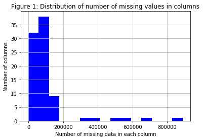

```python
# Investigate patterns in the amount of missing data in each column.
plt.hist(null_data, bins=15, color='b', alpha=1)
plt.xlabel('Number of missing data in each column')
plt.ylabel('Number of columns')
plt.title('Figure 1: Distribution of number of missing values in columns')
plt.grid(True)
plt.show()
```

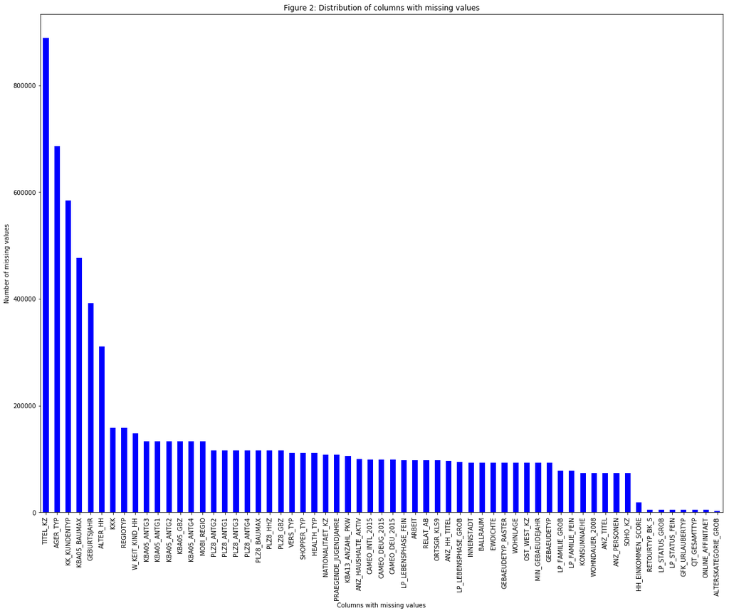

```
There are 61 columns with missing values.
```

```python
missing_columns = azdias_null[azdias_null['count'] > 0]
missing_columns.sort_values(by = 'count', ascending = False, inplace=True)
missing_columns.iloc[:, 0].plot.bar(figsize=(20,15), color='b')
plt.xlabel('Columns with missing values')
plt.ylabel('Number of missing values')
plt.title('Figure 2: Distribution of columns with missing values')
plt.show()
print("There are {} columns with missing values.".format(len(missing_columns)))
```

```python
# Remove the outlier columns from the dataset. (You'll perform other data
# engineering tasks such as re-encoding and imputation later.)
outliers = azdias_null[azdias_null['count'] > 200000]
print (outliers)
```

```
               count  percentage
AGER_TYP      685843       76.96
GEBURTSJAHR   392318       44.02
TITEL_KZ      889061       99.76
ALTER_HH      310267       34.81
KK_KUNDENTYP  584612       65.60
KBA05_BAUMAX  476524       53.47
```

```python
azdias = azdias.drop(outliers.index, axis = 1)
```

```python
azdias.shape
```

```
(891221, 79)
```

#### Discussion 1.1.2: Assess Missing Data in Each Column

Based on Figure 1 and Figure 2, there are 61 among 85 columns with missing values and 24 columns with complete values. The 6 columns with missing values over 200,000, or 20%, are seen as outliers and thus removed from the dataset. They are 'AGER_TYP', 'GEBURTSJAHR', 'TITEL_KZ', 'ALTER_HH', 'KK_KUNDENTYP', and 'KBA05_BAUMAX'. The remaining 79 columns would be used for modeling and analysis.

#### Step 1.1.3: Assess Missing Data in Each Row

Now, you'll perform a similar assessment for the rows of the dataset. How much data is missing in each row? As with the columns, you should see some groups of points that have a very different numbers of missing values. Divide the data into two subsets: one for data points that are above some threshold for missing values, and a second subset for points below that threshold.

In order to know what to do with the outlier rows, we should see if the distribution of data values on columns that are not missing data (or are missing very little data) are similar or different between the two groups. Select at least five of these columns and compare the distribution of values.

- You can use seaborn's [`countplot()`](https://seaborn.pydata.org/generated/seaborn.countplot.html) function to create a bar chart of code frequencies and matplotlib's [`subplot()`](https://matplotlib.org/api/_as_gen/matplotlib.pyplot.subplot.html) function to put bar charts for the two subplots side by side.
- To reduce repeated code, you might want to write a function that can perform this comparison, taking as one of its arguments a column to be compared.

Depending on what you observe in your comparison, this will have implications on how you approach your conclusions later in the analysis. If the distributions of non-missing features look similar between the data with many missing values and the data with few or no missing values, then we could argue that simply dropping those points from the analysis won't present a major issue. On the other hand, if the data with many missing values looks very different from the data with few or no missing values, then we should make a note on those data as special. We'll revisit these data later on. **Either way, you should continue your analysis for now using just the subset of the data with few or no missing values.**

```python
# How much data is missing in each row of the dataset?
null_data_row = azdias.isnull().sum(axis = 1)
null_data_row_dict = {'count': null_data_row.values,
                      'percentage':np.round(null_data_row.values/azdias.shape[1]*100,2)}
azdias_null_row = pd.DataFrame(data = null_data_row_dict, index = null_data_row.index)
azdias_null_row.sort_values(by = 'count', ascending = False)
```

|  | count | percentage |
| --- | --- | --- |
| 732775 | 49 | 62.03 |
| 643174 | 49 | 62.03 |
| 472919 | 48 | 60.76 |
| 345274 | 47 | 59.49 |
| 299868 | 47 | 59.49 |
| 582092 | 47 | 59.49 |
| 681255 | 47 | 59.49 |
| 818343 | 47 | 59.49 |
| 582109 | 47 | 59.49 |
| 439981 | 47 | 59.49 |
| 439979 | 47 | 59.49 |
| 299814 | 47 | 59.49 |
| 38748 | 47 | 59.49 |
| 299838 | 47 | 59.49 |
| 681206 | 47 | 59.49 |
| 299769 | 47 | 59.49 |
| 681204 | 47 | 59.49 |
| 439958 | 47 | 59.49 |
| 863655 | 47 | 59.49 |
| 863654 | 47 | 59.49 |
| 681203 | 47 | 59.49 |
| 681202 | 47 | 59.49 |
| 863651 | 47 | 59.49 |
| 582139 | 47 | 59.49 |
| 38761 | 47 | 59.49 |
| 38763 | 47 | 59.49 |
| 681273 | 47 | 59.49 |
| 818316 | 47 | 59.49 |
| 103633 | 47 | 59.49 |
| 582069 | 47 | 59.49 |
| ... | ... | ... |
| 349076 | 0 | 0.00 |
| 349078 | 0 | 0.00 |
| 349079 | 0 | 0.00 |
| 349081 | 0 | 0.00 |
| 349083 | 0 | 0.00 |
| 349084 | 0 | 0.00 |
| 349085 | 0 | 0.00 |
| 349054 | 0 | 0.00 |
| 349052 | 0 | 0.00 |
| 349028 | 0 | 0.00 |
| 349037 | 0 | 0.00 |
| 349029 | 0 | 0.00 |
| 349030 | 0 | 0.00 |
| 349031 | 0 | 0.00 |
| 349032 | 0 | 0.00 |
| 349033 | 0 | 0.00 |
| 349034 | 0 | 0.00 |
| 349035 | 0 | 0.00 |
| 349036 | 0 | 0.00 |
| 349041 | 0 | 0.00 |
| 349051 | 0 | 0.00 |
| 349043 | 0 | 0.00 |
| 349044 | 0 | 0.00 |
| 349045 | 0 | 0.00 |
| 349046 | 0 | 0.00 |
| 349047 | 0 | 0.00 |
| 349048 | 0 | 0.00 |
| 349049 | 0 | 0.00 |
| 349050 | 0 | 0.00 |
| 891220 | 0 | 0.00 |

891221 rows × 2 columns

```python
null_data_row.describe()
```

```
count    891221.000000
mean          5.649894
std          13.234687
min           0.000000
25%           0.000000
50%           0.000000
75%           3.000000
max          49.000000
dtype: float64
```

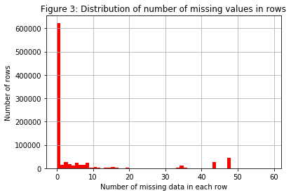

```python
# Plot the pattern in the number of missing data in each row
plt.hist(null_data_row, bins=np.arange(0, 60, 1), color='r', alpha=1)
plt.xlabel('Number of missing data in each row')
plt.ylabel('Number of rows')
plt.title('Figure 3: Distribution of number of missing values in rows')
plt.grid(True)
plt.show()
```

```python
complete_rows = azdias_null_row[azdias_null_row['count'] == 0]
print("There are {:0.2f}% rows with complete values.".format(len(complete_rows)/azdias.shape[0]*100))
more_than_10_rows = azdias_null_row[azdias_null_row['count'] > 10]
print("There are {:0.2f}% rows with more than 10 missing values.".format(len(more_than_10_rows)/azdias.shape[0]*100))
```

```
There are 69.93% rows with complete values.
There are 12.46% rows with more than 10 missing values.
```

##### There are 891221 rows with the mean of 5.65 missing values per row. Nearly 70% rows have no missing values and 75% of rows have 0 to 3 missing values. The most incoplete row has 49 missing values. The distribution is highly right-skewed with nearly 88% rows having missing values less or equal to 10. Based on Figure 3 above, this analysis will use 0 to split the rows into two subsets.

```python
# Write code to divide the data into two subsets based on the number of missing values in each row.
# Add a column to record the number of missing values of each row
azdias = azdias.assign(num_missing = null_data_row.values)
azdias.head(10)
```

|  | ALTERSKATEGORIE_GROB | ANREDE_KZ | CJT_GESAMTTYP | FINANZ_MINIMALIST | FINANZ_SPARER | FINANZ_VORSORGER | FINANZ_ANLEGER | FINANZ_UNAUFFAELLIGER | FINANZ_HAUSBAUER | FINANZTYP | ... | PLZ8_ANTG2 | PLZ8_ANTG3 | PLZ8_ANTG4 | PLZ8_BAUMAX | PLZ8_HHZ | PLZ8_GBZ | ARBEIT | ORTSGR_KLS9 | RELAT_AB | num_missing |
| --- | --- | --- | --- | --- | --- | --- | --- | --- | --- | --- | --- | --- | --- | --- | --- | --- | --- | --- | --- | --- | --- |
| 0 | 2.0 | 1 | 2.0 | 3 | 4 | 3 | 5 | 5 | 3 | 4 | ... | NaN | NaN | NaN | NaN | NaN | NaN | NaN | NaN | NaN | 43 |
| 1 | 1.0 | 2 | 5.0 | 1 | 5 | 2 | 5 | 4 | 5 | 1 | ... | 3.0 | 2.0 | 1.0 | 1.0 | 5.0 | 4.0 | 3.0 | 5.0 | 4.0 | 0 |
| 2 | 3.0 | 2 | 3.0 | 1 | 4 | 1 | 2 | 3 | 5 | 1 | ... | 3.0 | 1.0 | 0.0 | 1.0 | 4.0 | 4.0 | 3.0 | 5.0 | 2.0 | 0 |
| 3 | 4.0 | 2 | 2.0 | 4 | 2 | 5 | 2 | 1 | 2 | 6 | ... | 2.0 | 2.0 | 0.0 | 1.0 | 3.0 | 4.0 | 2.0 | 3.0 | 3.0 | 7 |
| 4 | 3.0 | 1 | 5.0 | 4 | 3 | 4 | 1 | 3 | 2 | 5 | ... | 4.0 | 2.0 | 1.0 | 2.0 | 3.0 | 3.0 | 4.0 | 6.0 | 5.0 | 0 |
| 5 | 1.0 | 2 | 2.0 | 3 | 1 | 5 | 2 | 2 | 5 | 2 | ... | 3.0 | 1.0 | 1.0 | 1.0 | 5.0 | 5.0 | 2.0 | 3.0 | 3.0 | 0 |
| 6 | 2.0 | 2 | 5.0 | 1 | 5 | 1 | 5 | 4 | 3 | 4 | ... | 3.0 | 1.0 | 0.0 | 1.0 | 5.0 | 5.0 | 4.0 | 6.0 | 3.0 | 0 |
| 7 | 1.0 | 1 | 3.0 | 3 | 3 | 4 | 1 | 3 | 2 | 5 | ... | 3.0 | 1.0 | 0.0 | 1.0 | 4.0 | 4.0 | 2.0 | 5.0 | 2.0 | 0 |
| 8 | 3.0 | 1 | 3.0 | 4 | 4 | 2 | 4 | 2 | 2 | 6 | ... | 3.0 | 2.0 | 1.0 | 1.0 | 3.0 | 3.0 | 2.0 | 4.0 | 3.0 | 0 |
| 9 | 3.0 | 2 | 4.0 | 2 | 4 | 2 | 3 | 5 | 4 | 1 | ... | 3.0 | 2.0 | 1.0 | 1.0 | 3.0 | 3.0 | 2.0 | 3.0 | 1.0 | 0 |

10 rows × 80 columns

```python
# Divide the data into two subsets with the split_value
split_value = 0
high_missing_rows = azdias[azdias['num_missing'] > split_value]
low_missing_rows = azdias[azdias['num_missing'] <= split_value]
```

```python
# Compare the distribution of values for at least five columns where there are
# no or few missing values, between the two subsets.
np.random.seed(98765)
sample_columns = np.random.choice(azdias.columns[:-1], 10).tolist()
print(sample_columns)
```

```
['RETOURTYP_BK_S', 'ANZ_HAUSHALTE_AKTIV', 'KONSUMNAEHE', 'VERS_TYP', 'FINANZTYP', 'FINANZ_SPARER', 'SEMIO_MAT', 'PLZ8_HHZ', 'LP_STATUS_GROB', 'PLZ8_ANTG4']
```

```python
# Compare the distribution of values between two subsets
def compare_dist_for_a_column(df, column_name, split_value):
    fig = plt.figure(figsize=(18, 8))
    ax1 = fig.add_subplot(121)
    ax1.title.set_text('High_missing_rows')
    sns.countplot(df.loc[df.num_missing > split_value, column_name])

    ax2 = fig.add_subplot(122)
    ax2.title.set_text('Low_missing_rows')
    sns.countplot(df.loc[df.num_missing <= split_value, column_name])

    fig.suptitle(column_name)
    plt.show();

    # If the p-value < 0.05, then reject the null hypothesis that the two distributions are the same.
    print(stats.ks_2samp(df.loc[df.num_missing <= split_value, column_name], df.loc[df.num_missing > split_value, column_name]))
```

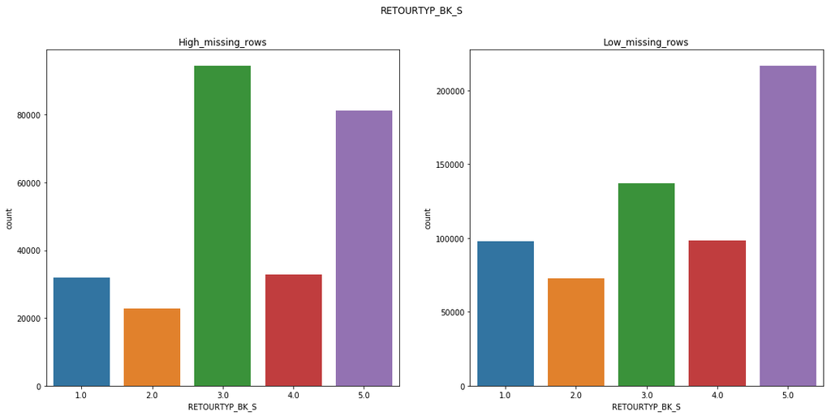

```
Ks_2sampResult(statistic=0.069958597207328166, pvalue=0.0)
```

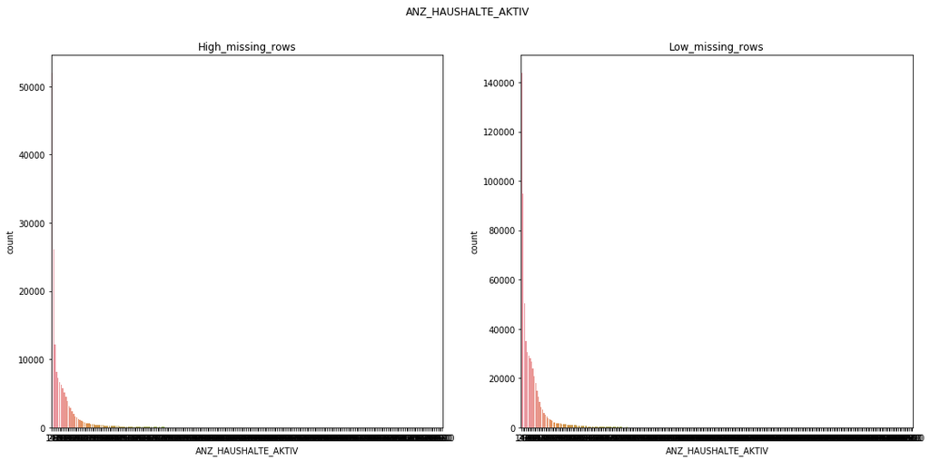

```
Ks_2sampResult(statistic=0.37170273264703313, pvalue=0.0)
```

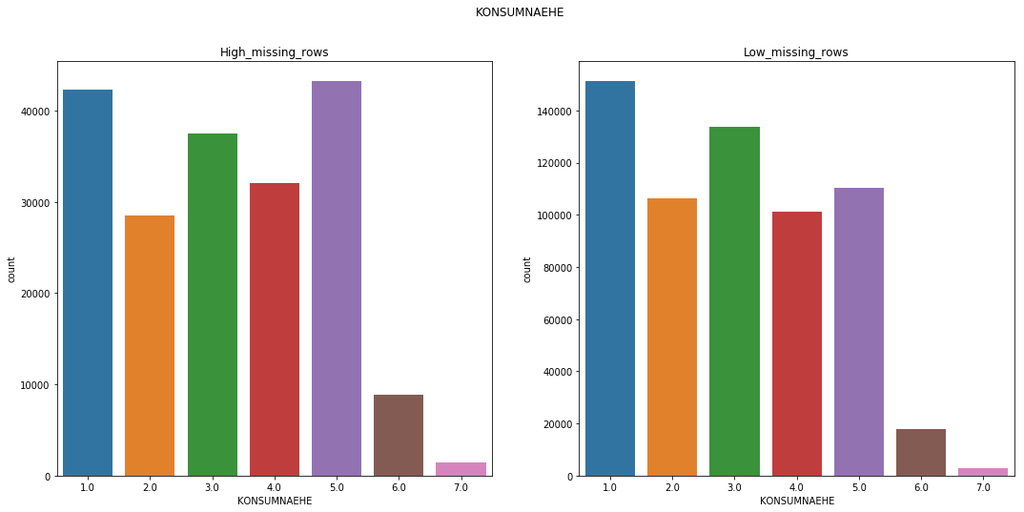

```
Ks_2sampResult(statistic=0.28121904186634616, pvalue=0.0)
```

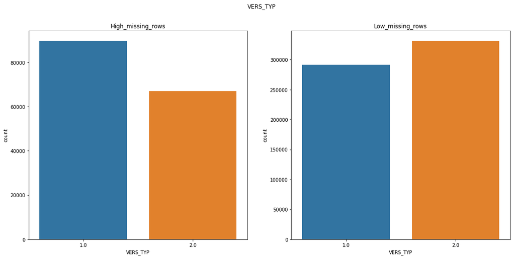

```
Ks_2sampResult(statistic=0.4148918705132606, pvalue=0.0)
```

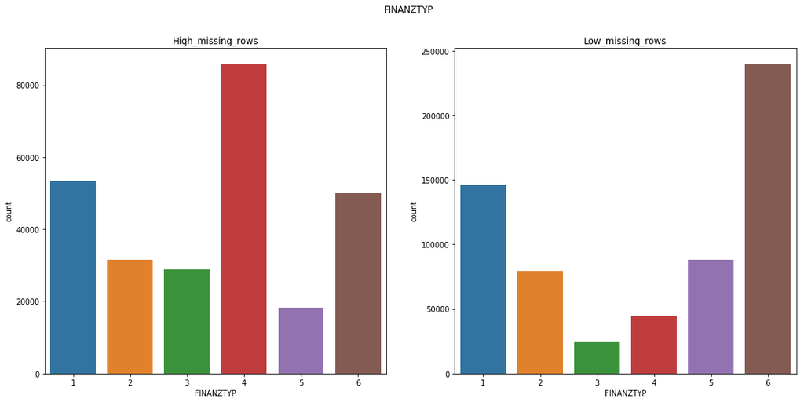

```
Ks_2sampResult(statistic=0.2717850748157275, pvalue=0.0)
```

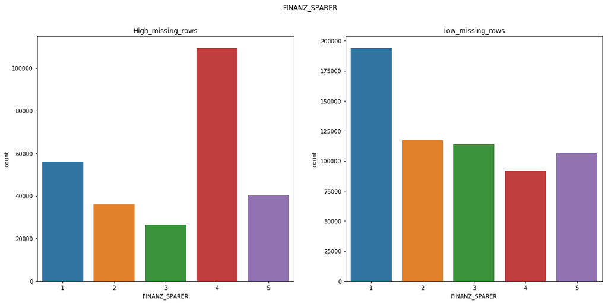

```
Ks_2sampResult(statistic=0.24085289286001205, pvalue=0.0)
```

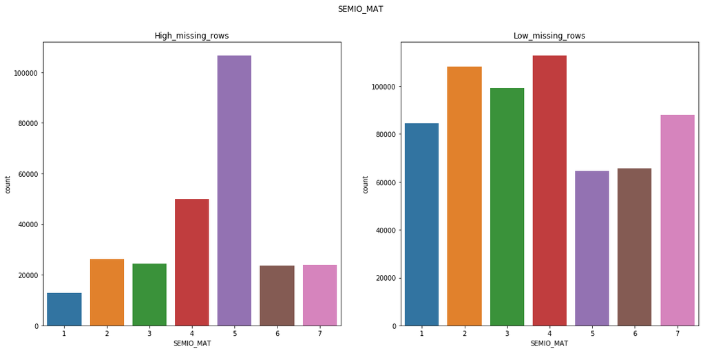

```
Ks_2sampResult(statistic=0.23088391755579254, pvalue=0.0)
```

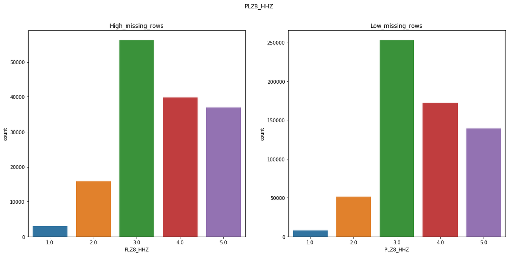

```
Ks_2sampResult(statistic=0.43473799680611314, pvalue=0.0)
```

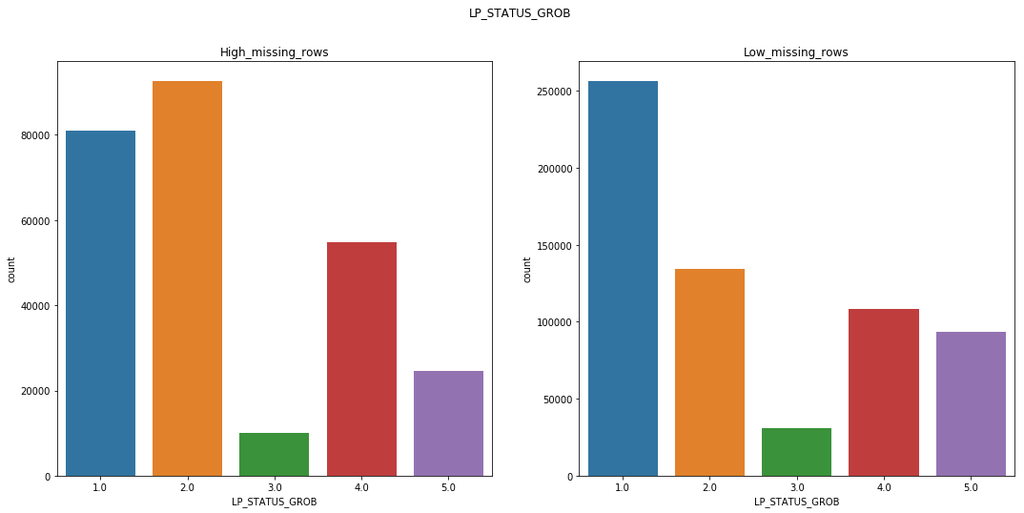

```
Ks_2sampResult(statistic=0.10973996750625958, pvalue=0.0)
```

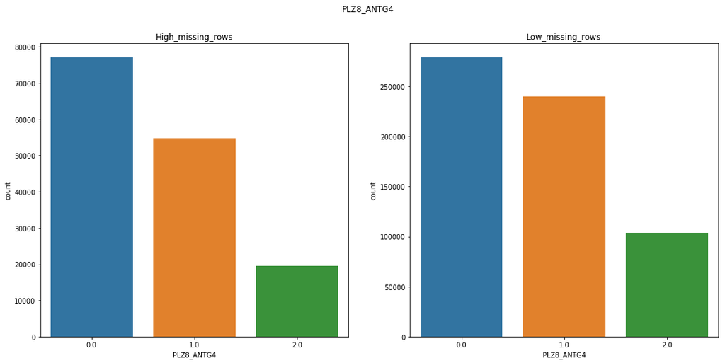

```
Ks_2sampResult(statistic=0.43473799680611314, pvalue=0.0)
```

```python
for col in sample_columns:
    compare_dist_for_a_column(azdias, col, split_value)
```

#### Discussion 1.1.3: Assess Missing Data in Each Row

There are 891221 rows with the mean of 5.65 missing values per row. Nearly 70% rows have no missing values and 75% of rows have 0 to 3 missing values. The most incoplete row has 49 missing values. The distribution is highly right-skewed with nearly 88% rows having missing values less or equal to 10. Based on Figure 3 above, this analysis tried to use 0 to split the rows into two subsets to compare the data distribution between high_missing_rows subset and low_missing_rows subset (which is complete rows with the 0 to split).

The results of 10 sample columns between the two subsets have p_value < 0.05, so we need to reject the null hypothesis that the two distributions are the same. Thus, the subset data with lots of missing values overall are qualitatively different from the subset data with few or no missing values. However, since dropping off all incomplete rows would still reserve 70% of the original data, I will be proceeding my analysis with rows without any missing value.

```python
# Remove all rows with no missing values
azdias = azdias[azdias.num_missing == 0]
```

```python
# Check data
azdias.shape
```

```
(623209, 80)
```

```python
azdias.isnull().sum(axis=1).sum()
```

```
0
```

### Step 1.2: Select and Re-Encode Features

Checking for missing data isn't the only way in which you can prepare a dataset for analysis. Since the unsupervised learning techniques to be used will only work on data that is encoded numerically, you need to make a few encoding changes or additional assumptions to be able to make progress. In addition, while almost all of the values in the dataset are encoded using numbers, not all of them represent numeric values. Check the third column of the feature summary (`feat_info`) for a summary of types of measurement.

- For numeric and interval data, these features can be kept without changes.
- Most of the variables in the dataset are ordinal in nature. While ordinal values may technically be non-linear in spacing, make the simplifying assumption that the ordinal variables can be treated as being interval in nature (that is, kept without any changes).
- Special handling may be necessary for the remaining two variable types: categorical, and 'mixed'.

In the first two parts of this sub-step, you will perform an investigation of the categorical and mixed-type features and make a decision on each of them, whether you will keep, drop, or re-encode each. Then, in the last part, you will create a new data frame with only the selected and engineered columns.

Data wrangling is often the trickiest part of the data analysis process, and there's a lot of it to be done here. But stick with it: once you're done with this step, you'll be ready to get to the machine learning parts of the project!

```python
# How many features are there of each data type?
feat_info.groupby(['type']).count()
```

| type | attribute | information_level | missing_or_unknown |
| --- | --- | --- | --- |
| categorical | 21 | 21 | 21 |
| interval | 1 | 1 | 1 |
| mixed | 7 | 7 | 7 |
| numeric | 7 | 7 | 7 |
| ordinal | 49 | 49 | 49 |

##### There are 7 numerical, 49 ordinal, and 1 interval data, which can be kept without any change. There are 21 categorical and 7 mixed data, which we need to take a deeper look to determine to keep, drop, or encode.

#### Step 1.2.1: Re-Encode Categorical Features

For categorical data, you would ordinarily need to encode the levels as dummy variables. Depending on the number of categories, perform one of the following:

- For binary (two-level) categoricals that take numeric values, you can keep them without needing to do anything.
- There is one binary variable that takes on non-numeric values. For this one, you need to re-encode the values as numbers or create a dummy variable.
- For multi-level categoricals (three or more values), you can choose to encode the values using multiple dummy variables (e.g. via [OneHotEncoder](http://scikit-learn.org/stable/modules/generated/sklearn.preprocessing.OneHotEncoder.html)), or (to keep things straightforward) just drop them from the analysis. As always, document your choices in the Discussion section.

```python
# Assess categorical variables: which are binary, which are multi-level, and
# which one needs to be re-encoded?
categorical_data = feat_info[feat_info['type'] == 'categorical']['attribute'].values
```

```python
categorical = [x for x in categorical_data if x in azdias.columns] # only the ones that are kept in azdias dataset
binary = [x for x in categorical if azdias[x].nunique()==2]
multilevel = [x for x in categorical if azdias[x].nunique()>2]
azdias[categorical].nunique()
```

```
ANREDE_KZ            2
CJT_GESAMTTYP        6
FINANZTYP            6
GFK_URLAUBERTYP     12
GREEN_AVANTGARDE     2
LP_FAMILIE_FEIN     11
LP_FAMILIE_GROB      5
LP_STATUS_FEIN      10
LP_STATUS_GROB       5
NATIONALITAET_KZ     3
SHOPPER_TYP          4
SOHO_KZ              2
VERS_TYP             2
ZABEOTYP             6
GEBAEUDETYP          4
OST_WEST_KZ          2
CAMEO_DEUG_2015      9
CAMEO_DEU_2015      44
dtype: int64
```

```python
# Drop 'CAMEO DEU_2015' with 44 features which is too granular for a single column
multilevel.remove('CAMEO_DEU_2015')
azdias.drop('CAMEO_DEU_2015', axis=1, inplace=True)
```

```python
# Check all binary variables which attribute with non-numerical values
azdias.loc[:, binary]
```

|  | ANREDE_KZ | GREEN_AVANTGARDE | SOHO_KZ | VERS_TYP | OST_WEST_KZ |
| --- | --- | --- | --- | --- | --- |
| 1 | 2 | 0 | 1.0 | 2.0 | W |
| 2 | 2 | 1 | 0.0 | 1.0 | W |
| 4 | 1 | 0 | 0.0 | 2.0 | W |
| 5 | 2 | 0 | 0.0 | 2.0 | W |
| 6 | 2 | 0 | 0.0 | 1.0 | W |
| 7 | 1 | 0 | 0.0 | 1.0 | W |
| 8 | 1 | 1 | 0.0 | 2.0 | W |
| 9 | 2 | 1 | 0.0 | 2.0 | W |
| 10 | 2 | 0 | 0.0 | 2.0 | W |
| 19 | 1 | 1 | 0.0 | 2.0 | W |
| 21 | 1 | 0 | 0.0 | 2.0 | W |
| 22 | 1 | 0 | 0.0 | 2.0 | W |
| 27 | 1 | 1 | 0.0 | 2.0 | W |
| 28 | 1 | 0 | 0.0 | 2.0 | W |
| 31 | 2 | 0 | 0.0 | 1.0 | W |
| 32 | 1 | 1 | 0.0 | 1.0 | W |
| 33 | 2 | 0 | 0.0 | 2.0 | W |
| 36 | 2 | 0 | 0.0 | 2.0 | W |
| 37 | 1 | 0 | 0.0 | 2.0 | W |
| 38 | 2 | 0 | 0.0 | 1.0 | W |
| 41 | 2 | 1 | 0.0 | 2.0 | W |
| 43 | 2 | 0 | 0.0 | 1.0 | W |
| 44 | 2 | 0 | 0.0 | 1.0 | W |
| 45 | 2 | 0 | 0.0 | 1.0 | W |
| 47 | 2 | 1 | 0.0 | 1.0 | W |
| 49 | 1 | 0 | 0.0 | 1.0 | W |
| 50 | 1 | 0 | 0.0 | 2.0 | W |
| 51 | 1 | 1 | 0.0 | 1.0 | W |
| 52 | 2 | 0 | 0.0 | 2.0 | W |
| 55 | 2 | 0 | 0.0 | 1.0 | W |
| ... | ... | ... | ... | ... | ... |
| 891183 | 1 | 1 | 0.0 | 2.0 | W |
| 891186 | 1 | 1 | 0.0 | 1.0 | W |
| 891188 | 2 | 0 | 0.0 | 2.0 | W |
| 891189 | 2 | 1 | 0.0 | 1.0 | W |
| 891190 | 1 | 1 | 0.0 | 2.0 | W |
| 891191 | 2 | 0 | 0.0 | 2.0 | W |
| 891192 | 2 | 0 | 0.0 | 1.0 | W |
| 891193 | 1 | 0 | 0.0 | 1.0 | W |
| 891194 | 1 | 1 | 0.0 | 2.0 | W |
| 891195 | 2 | 0 | 0.0 | 2.0 | W |
| 891196 | 2 | 0 | 0.0 | 1.0 | W |
| 891197 | 2 | 1 | 0.0 | 2.0 | W |
| 891198 | 1 | 1 | 0.0 | 2.0 | W |
| 891199 | 1 | 0 | 0.0 | 1.0 | W |
| 891200 | 2 | 0 | 0.0 | 2.0 | W |
| 891201 | 1 | 0 | 0.0 | 2.0 | W |
| 891202 | 2 | 0 | 0.0 | 1.0 | W |
| 891204 | 1 | 0 | 0.0 | 2.0 | W |
| 891205 | 1 | 0 | 0.0 | 1.0 | W |
| 891206 | 2 | 0 | 0.0 | 2.0 | W |
| 891207 | 2 | 1 | 0.0 | 1.0 | W |
| 891209 | 2 | 0 | 0.0 | 2.0 | W |
| 891210 | 1 | 0 | 0.0 | 2.0 | W |
| 891211 | 1 | 0 | 0.0 | 1.0 | W |
| 891212 | 1 | 0 | 0.0 | 1.0 | W |
| 891213 | 2 | 1 | 0.0 | 1.0 | W |
| 891214 | 2 | 0 | 0.0 | 2.0 | W |
| 891215 | 2 | 0 | 0.0 | 1.0 | W |
| 891219 | 1 | 0 | 0.0 | 2.0 | W |
| 891220 | 1 | 0 | 0.0 | 1.0 | W |

623209 rows × 5 columns

```python
azdias.loc[:, 'OST_WEST_KZ'].unique()
```

```
array(['W', 'O'], dtype=object)
```

```python
# Convert binary variable with non-numeric values into a binary variable with numeric values
azdias.loc[:, 'OST_WEST_KZ'].replace({'W':0, 'O':1}, inplace=True)
```

```python
# Check binary values
azdias.loc[:, binary]
```

|  | ANREDE_KZ | GREEN_AVANTGARDE | SOHO_KZ | VERS_TYP | OST_WEST_KZ |
| --- | --- | --- | --- | --- | --- |
| 1 | 2 | 0 | 1.0 | 2.0 | 0 |
| 2 | 2 | 1 | 0.0 | 1.0 | 0 |
| 4 | 1 | 0 | 0.0 | 2.0 | 0 |
| 5 | 2 | 0 | 0.0 | 2.0 | 0 |
| 6 | 2 | 0 | 0.0 | 1.0 | 0 |
| 7 | 1 | 0 | 0.0 | 1.0 | 0 |
| 8 | 1 | 1 | 0.0 | 2.0 | 0 |
| 9 | 2 | 1 | 0.0 | 2.0 | 0 |
| 10 | 2 | 0 | 0.0 | 2.0 | 0 |
| 19 | 1 | 1 | 0.0 | 2.0 | 0 |
| 21 | 1 | 0 | 0.0 | 2.0 | 0 |
| 22 | 1 | 0 | 0.0 | 2.0 | 0 |
| 27 | 1 | 1 | 0.0 | 2.0 | 0 |
| 28 | 1 | 0 | 0.0 | 2.0 | 0 |
| 31 | 2 | 0 | 0.0 | 1.0 | 0 |
| 32 | 1 | 1 | 0.0 | 1.0 | 0 |
| 33 | 2 | 0 | 0.0 | 2.0 | 0 |
| 36 | 2 | 0 | 0.0 | 2.0 | 0 |
| 37 | 1 | 0 | 0.0 | 2.0 | 0 |
| 38 | 2 | 0 | 0.0 | 1.0 | 0 |
| 41 | 2 | 1 | 0.0 | 2.0 | 0 |
| 43 | 2 | 0 | 0.0 | 1.0 | 0 |
| 44 | 2 | 0 | 0.0 | 1.0 | 0 |
| 45 | 2 | 0 | 0.0 | 1.0 | 0 |
| 47 | 2 | 1 | 0.0 | 1.0 | 0 |
| 49 | 1 | 0 | 0.0 | 1.0 | 0 |
| 50 | 1 | 0 | 0.0 | 2.0 | 0 |
| 51 | 1 | 1 | 0.0 | 1.0 | 0 |
| 52 | 2 | 0 | 0.0 | 2.0 | 0 |
| 55 | 2 | 0 | 0.0 | 1.0 | 0 |
| ... | ... | ... | ... | ... | ... |
| 891183 | 1 | 1 | 0.0 | 2.0 | 0 |
| 891186 | 1 | 1 | 0.0 | 1.0 | 0 |
| 891188 | 2 | 0 | 0.0 | 2.0 | 0 |
| 891189 | 2 | 1 | 0.0 | 1.0 | 0 |
| 891190 | 1 | 1 | 0.0 | 2.0 | 0 |
| 891191 | 2 | 0 | 0.0 | 2.0 | 0 |
| 891192 | 2 | 0 | 0.0 | 1.0 | 0 |
| 891193 | 1 | 0 | 0.0 | 1.0 | 0 |
| 891194 | 1 | 1 | 0.0 | 2.0 | 0 |
| 891195 | 2 | 0 | 0.0 | 2.0 | 0 |
| 891196 | 2 | 0 | 0.0 | 1.0 | 0 |
| 891197 | 2 | 1 | 0.0 | 2.0 | 0 |
| 891198 | 1 | 1 | 0.0 | 2.0 | 0 |
| 891199 | 1 | 0 | 0.0 | 1.0 | 0 |
| 891200 | 2 | 0 | 0.0 | 2.0 | 0 |
| 891201 | 1 | 0 | 0.0 | 2.0 | 0 |
| 891202 | 2 | 0 | 0.0 | 1.0 | 0 |
| 891204 | 1 | 0 | 0.0 | 2.0 | 0 |
| 891205 | 1 | 0 | 0.0 | 1.0 | 0 |
| 891206 | 2 | 0 | 0.0 | 2.0 | 0 |
| 891207 | 2 | 1 | 0.0 | 1.0 | 0 |
| 891209 | 2 | 0 | 0.0 | 2.0 | 0 |
| 891210 | 1 | 0 | 0.0 | 2.0 | 0 |
| 891211 | 1 | 0 | 0.0 | 1.0 | 0 |
| 891212 | 1 | 0 | 0.0 | 1.0 | 0 |
| 891213 | 2 | 1 | 0.0 | 1.0 | 0 |
| 891214 | 2 | 0 | 0.0 | 2.0 | 0 |
| 891215 | 2 | 0 | 0.0 | 1.0 | 0 |
| 891219 | 1 | 0 | 0.0 | 2.0 | 0 |
| 891220 | 1 | 0 | 0.0 | 1.0 | 0 |

623209 rows × 5 columns

```python
# Check multilevel values
print(multilevel)
```

```
['CJT_GESAMTTYP', 'FINANZTYP', 'GFK_URLAUBERTYP', 'LP_FAMILIE_FEIN', 'LP_FAMILIE_GROB', 'LP_STATUS_FEIN', 'LP_STATUS_GROB', 'NATIONALITAET_KZ', 'SHOPPER_TYP', 'ZABEOTYP', 'GEBAEUDETYP', 'CAMEO_DEUG_2015']
```

```python
# Re-encode multilevel categorical variable(s) to be kept in the analysis.
for col in multilevel:
    dummies = pd.get_dummies(azdias[col], prefix = col)
    azdias = azdias.join(dummies)
    azdias.drop([col], axis=1, inplace=True)
```

```python
azdias.columns
```

```
Index(['ALTERSKATEGORIE_GROB', 'ANREDE_KZ', 'FINANZ_MINIMALIST',
       'FINANZ_SPARER', 'FINANZ_VORSORGER', 'FINANZ_ANLEGER',
       'FINANZ_UNAUFFAELLIGER', 'FINANZ_HAUSBAUER', 'GREEN_AVANTGARDE',
       'HEALTH_TYP',
       ...
       'GEBAEUDETYP_8.0', 'CAMEO_DEUG_2015_1', 'CAMEO_DEUG_2015_2',
       'CAMEO_DEUG_2015_3', 'CAMEO_DEUG_2015_4', 'CAMEO_DEUG_2015_5',
       'CAMEO_DEUG_2015_6', 'CAMEO_DEUG_2015_7', 'CAMEO_DEUG_2015_8',
       'CAMEO_DEUG_2015_9'],
      dtype='object', length=148)
```

#### Discussion 1.2.1: Re-Encode Categorical Features

There are 7 numerical, 49 ordinal, and 1 interval data, which can be kept without any change. There are 21 categorical and 7 mixed data, which we need to take a deeper look to determine to keep, drop, or encode. For all categorical features, since 'CAMEO_DEU_2015' has 44 differrent values which will result in 44 dummy variables alone while explain very little information, this feature was removed from the dataset. Also, we found 'OST_WEST_KZ' has non-numerical binary variables, which were converted into a numeric binary variable replacing 'W' with 0 and 'O' with 1. Then for every remaining 12 multilevel caegorical variable, we did encode the values using multiple dummy variables, which results in 148 columns in total.

#### Step 1.2.2: Engineer Mixed-Type Features

There are a handful of features that are marked as "mixed" in the feature summary that require special treatment in order to be included in the analysis. There are two in particular that deserve attention; the handling of the rest are up to your own choices:

- "PRAEGENDE_JUGENDJAHRE" combines information on three dimensions: generation by decade, movement (mainstream vs. avantgarde), and nation (east vs. west). While there aren't enough levels to disentangle east from west, you should create two new variables to capture the other two dimensions: an interval-type variable for decade, and a binary variable for movement.
- "CAMEO_INTL_2015" combines information on two axes: wealth and life stage. Break up the two-digit codes by their 'tens'-place and 'ones'-place digits into two new ordinal variables (which, for the purposes of this project, is equivalent to just treating them as their raw numeric values).
- If you decide to keep or engineer new features around the other mixed-type features, make sure you note your steps in the Discussion section.

Be sure to check `Data_Dictionary.md` for the details needed to finish these tasks.

```python
# Check mixed data
mixed_data = feat_info[feat_info['type'] == 'mixed']['attribute'].values
mixed = [x for x in mixed_data if x in azdias.columns]
azdias[mixed].nunique()
```

```
LP_LEBENSPHASE_FEIN      40
LP_LEBENSPHASE_GROB      12
PRAEGENDE_JUGENDJAHRE    15
WOHNLAGE                  8
CAMEO_INTL_2015          21
PLZ8_BAUMAX               5
dtype: int64
```

```python
# Remove column 'LP_LEBENSPHASE_FEIN'
mixed.remove('LP_LEBENSPHASE_FEIN')
azdias.drop('LP_LEBENSPHASE_FEIN', axis=1, inplace=True)
```

```python
# Investigate "PRAEGENDE_JUGENDJAHRE" and engineer two new variables.
# Create a binary variable for movement based on the Data_Dictionary
mainstream = [1, 3, 5, 8, 10, 12, 14]
avantgarde = [2, 4, 6, 7, 9, 11, 13, 15]

def movement(x):
    if x in mainstream:
        return 1
    elif x in avantgarde:
        return 0
    else:
        return x

azdias['PRAEGENDE_JUGENDJAHRE_MOVEMENT'] = azdias['PRAEGENDE_JUGENDJAHRE'].apply(movement)
```

```python
# Create an interval-type variable for decade and map it to PRAEGENDE_JUGENDJAHRE based on the Data_Dictionary
x = [x+1 for x in range(15)]
y = [40, 40, 50, 50, 60, 60, 60, 70, 70, 80, 80, 80, 80, 90, 90]
decade = pd.Series(y, index = x)
azdias['PRAEGENDE_JUGENDJAHRE_DECADE'] = azdias['PRAEGENDE_JUGENDJAHRE'].map(decade)
```

```python
# Investigate "CAMEO_INTL_2015" and engineer two new variables.
azdias['CAMEO_INTL_2015_WEALTH'] = azdias.loc[:,'CAMEO_INTL_2015'].map(lambda x:int(str(x)[0]))
azdias['CAMEO_INTL_2015_LIFESTAGE'] = azdias.loc[:,'CAMEO_INTL_2015'].map(lambda x:int(str(x)[1]))
```

```python
# Add new variables into mixed variables list
mixed.append('PRAEGENDE_JUGENDJAHRE_MOVEMENT')
mixed.append('PRAEGENDE_JUGENDJAHRE_DECADE')
mixed.append('CAMEO_INTL_2015_WEALTH')
mixed.append('CAMEO_INTL_2015_LIFESTAGE')
```

```python
# Remove "PRAEGENDE_JUGENDJAHRE" and "CAMEO_INTL_2015" from the mixed list and dataset
mixed.remove('PRAEGENDE_JUGENDJAHRE')
azdias.drop('PRAEGENDE_JUGENDJAHRE', axis=1, inplace=True)
mixed.remove('CAMEO_INTL_2015')
azdias.drop('CAMEO_INTL_2015', axis=1, inplace=True)
```

```python
azdias[mixed].nunique()
```

```
LP_LEBENSPHASE_GROB               12
WOHNLAGE                           8
PLZ8_BAUMAX                        5
PRAEGENDE_JUGENDJAHRE_MOVEMENT     2
PRAEGENDE_JUGENDJAHRE_DECADE       6
CAMEO_INTL_2015_WEALTH             5
CAMEO_INTL_2015_LIFESTAGE          5
dtype: int64
```

```python
# Re-encode mixed variable(s) to be kept in the analysis
for col in mixed:
    dummies = pd.get_dummies(azdias[col], prefix = col)
    azdias = azdias.join(dummies)
    azdias.drop([col], axis=1, inplace=True)
```

```python
# Check data
azdias.shape
```

```
(623209, 185)
```

#### Discussion 1.2.2: Engineer Mixed-Type Features

For all the 6 mixed-data variables, firstly use the Data_Dictionary to check the meaning of each. LP_LEBENSPHASE_FINE was removed from the data since it has 40 different values and LP_LEBENSPHASE_GROB should suffice based on the definition. For features PRAEGENDE_JUGENDJAHRE and CAMEO_INTL_2015, we split them into two features each and removed the original features. Then, for all the remianing mixed features, use one-hot encoding to create dummy variables like the categorical data, which results in 185 columns in total.

#### Step 1.2.3: Complete Feature Selection

In order to finish this step up, you need to make sure that your data frame now only has the columns that you want to keep. To summarize, the dataframe should consist of the following:

- All numeric, interval, and ordinal type columns from the original dataset.
- Binary categorical features (all numerically-encoded).
- Engineered features from other multi-level categorical features and mixed features.

Make sure that for any new columns that you have engineered, that you've excluded the original columns from the final dataset. Otherwise, their values will interfere with the analysis later on the project. For example, you should not keep "PRAEGENDE_JUGENDJAHRE", since its values won't be useful for the algorithm: only the values derived from it in the engineered features you created should be retained. As a reminder, your data should only be from **the subset with few or no missing values**.

```python
# If there are other re-engineering tasks you need to perform, make sure you
# take care of them here. (Dealing with missing data will come in step 2.1.)
azdias.isnull().sum(axis=1).sum()
```

```
0
```

```python
# Do whatever you need to in order to ensure that the dataframe only contains
# the columns that should be passed to the algorithm functions.
azdias[azdias.columns].nunique()
```

```
ALTERSKATEGORIE_GROB                 4
ANREDE_KZ                            2
FINANZ_MINIMALIST                    5
FINANZ_SPARER                        5
FINANZ_VORSORGER                     5
FINANZ_ANLEGER                       5
FINANZ_UNAUFFAELLIGER                5
FINANZ_HAUSBAUER                     5
GREEN_AVANTGARDE                     2
HEALTH_TYP                           3
RETOURTYP_BK_S                       5
SEMIO_SOZ                            7
SEMIO_FAM                            7
SEMIO_REL                            7
SEMIO_MAT                            7
SEMIO_VERT                           7
SEMIO_LUST                           7
SEMIO_ERL                            7
SEMIO_KULT                           7
SEMIO_RAT                            7
SEMIO_KRIT                           7
SEMIO_DOM                            7
SEMIO_KAEM                           7
SEMIO_PFLICHT                        7
SEMIO_TRADV                          7
SOHO_KZ                              2
VERS_TYP                             2
ANZ_PERSONEN                        24
ANZ_TITEL                            5
HH_EINKOMMEN_SCORE                   6
                                    ..
WOHNLAGE_1.0                         2
WOHNLAGE_2.0                         2
WOHNLAGE_3.0                         2
WOHNLAGE_4.0                         2
WOHNLAGE_5.0                         2
WOHNLAGE_7.0                         2
WOHNLAGE_8.0                         2
PLZ8_BAUMAX_1.0                      2
PLZ8_BAUMAX_2.0                      2
PLZ8_BAUMAX_3.0                      2
PLZ8_BAUMAX_4.0                      2
PLZ8_BAUMAX_5.0                      2
PRAEGENDE_JUGENDJAHRE_MOVEMENT_0     2
PRAEGENDE_JUGENDJAHRE_MOVEMENT_1     2
PRAEGENDE_JUGENDJAHRE_DECADE_40      2
PRAEGENDE_JUGENDJAHRE_DECADE_50      2
PRAEGENDE_JUGENDJAHRE_DECADE_60      2
PRAEGENDE_JUGENDJAHRE_DECADE_70      2
PRAEGENDE_JUGENDJAHRE_DECADE_80      2
PRAEGENDE_JUGENDJAHRE_DECADE_90      2
CAMEO_INTL_2015_WEALTH_1             2
CAMEO_INTL_2015_WEALTH_2             2
CAMEO_INTL_2015_WEALTH_3             2
CAMEO_INTL_2015_WEALTH_4             2
CAMEO_INTL_2015_WEALTH_5             2
CAMEO_INTL_2015_LIFESTAGE_1          2
CAMEO_INTL_2015_LIFESTAGE_2          2
CAMEO_INTL_2015_LIFESTAGE_3          2
CAMEO_INTL_2015_LIFESTAGE_4          2
CAMEO_INTL_2015_LIFESTAGE_5          2
Length: 185, dtype: int64
```

### Step 1.3: Create a Cleaning Function

Even though you've finished cleaning up the general population demographics data, it's important to look ahead to the future and realize that you'll need to perform the same cleaning steps on the customer demographics data. In this substep, complete the function below to execute the main feature selection, encoding, and re-engineering steps you performed above. Then, when it comes to looking at the customer data in Step 3, you can just run this function on that DataFrame to get the trimmed dataset in a single step.

```python
def clean_data(df):
    """
    Perform feature trimming, re-encoding, and engineering for demographics
    data

    INPUT: Demographics DataFrame
    OUTPUT: Trimmed and cleaned demographics DataFrame
    """

    # Put in code here to execute all main cleaning steps:
    # convert missing value codes into NaNs, ...
    for index in feat_info.index:
        for item in range(len(feat_info.loc[index, 'missing_or_unknown'])):
            df.loc[:,(feat_info.loc[index, 'attribute'])].replace(feat_info.loc[index, 'missing_or_unknown'], np.nan, inplace=True)

    # remove selected columns and rows, ...
    df = df.drop(outliers.index, axis = 1)
    num_missing = df.isnull().transpose().sum()
    df = df[num_missing == 0]
    df.drop('CAMEO_DEU_2015', axis=1, inplace=True) # Drop CAMEO_DEU_2015 due to too much detail

    # select, re-encode, and engineer column values....
    categorical_data = feat_info[feat_info['type'] == 'categorical']['attribute'].values
    df_categorical = [x for x in categorical_data if x in df.columns] # only the ones that are kept in df dataset
    df_binary = [x for x in df_categorical if df[x].nunique()==2]
    df_multilevel = [x for x in df_categorical if df[x].nunique()>2]
    mixed_data = feat_info[feat_info['type'] == 'mixed']['attribute'].values
    df_mixed = [x for x in mixed_data if x in df.columns] # only the ones that are kept in df_lowmiss dataset
    df.loc[:, 'OST_WEST_KZ'].replace({'W':0, 'O':1}, inplace=True); # Convert OST_WEST_KZ into binary categorical

    # onehotencode multilevel
    for col in df_multilevel:
        dummies = pd.get_dummies(df[col], prefix = col)
        df = df.join(dummies)
        df.drop([col], axis=1, inplace=True)


    # Remove column 'LP_LEBENSPHASE_FEIN'
    df_mixed.remove('LP_LEBENSPHASE_FEIN')
    df.drop('LP_LEBENSPHASE_FEIN', axis=1, inplace=True)

    # Investigate "PRAEGENDE_JUGENDJAHRE" and engineer two new variables.
    # Create a binary variable for movement based on the Data_Dictionary
    mainstream = [1, 3, 5, 8, 10, 12, 14]
    avantgarde = [2, 4, 6, 7, 9, 11, 13, 15]
    def movement(x):
        if x in mainstream:
            return 1
        elif x in avantgarde:
            return 0
        else:
            return x

    df['PRAEGENDE_JUGENDJAHRE_MOVEMENT'] = df['PRAEGENDE_JUGENDJAHRE'].apply(movement)

    # Create an interval-type variable for decade and map it to PRAEGENDE_JUGENDJAHRE based on the Data_Dictionary
    x = [x+1 for x in range(15)]
    y = [40, 40, 50, 50, 60, 60, 60, 70, 70, 80, 80, 80, 80, 90, 90]
    decade = pd.Series(y, index = x)
    df['PRAEGENDE_JUGENDJAHRE_DECADE'] = df['PRAEGENDE_JUGENDJAHRE'].map(decade)

    # Investigate "CAMEO_INTL_2015" and engineer two new variables.
    df['CAMEO_INTL_2015_WEALTH'] = df.loc[:,'CAMEO_INTL_2015'].map(lambda x:int(str(x)[0]))
    df['CAMEO_INTL_2015_LIFESTAGE'] = df.loc[:,'CAMEO_INTL_2015'].map(lambda x:int(str(x)[1]))

    # Add new variables into mixed variables list
    df_mixed.append('PRAEGENDE_JUGENDJAHRE_MOVEMENT')
    df_mixed.append('PRAEGENDE_JUGENDJAHRE_DECADE')
    df_mixed.append('CAMEO_INTL_2015_WEALTH')
    df_mixed.append('CAMEO_INTL_2015_LIFESTAGE')

    # Remove "PRAEGENDE_JUGENDJAHRE" and "CAMEO_INTL_2015" from the mixed list and dataset
    df_mixed.remove('PRAEGENDE_JUGENDJAHRE')
    df.drop('PRAEGENDE_JUGENDJAHRE', axis=1, inplace=True)
    df_mixed.remove('CAMEO_INTL_2015')
    df.drop('CAMEO_INTL_2015', axis=1, inplace=True)

    # onehotencode mixed
    for col in df_mixed:
        dummies = pd.get_dummies(df[col], prefix = col)
        df = df.join(dummies)
        df.drop([col], axis=1, inplace=True)

    # Return the cleaned dataframe.
    return df
```

## Step 2: Feature Transformation

### Step 2.1: Apply Feature Scaling

Before we apply dimensionality reduction techniques to the data, we need to perform feature scaling so that the principal component vectors are not influenced by the natural differences in scale for features. Starting from this part of the project, you'll want to keep an eye on the [API reference page for sklearn](http://scikit-learn.org/stable/modules/classes.html) to help you navigate to all of the classes and functions that you'll need. In this substep, you'll need to check the following:

- sklearn requires that data not have missing values in order for its estimators to work properly. So, before applying the scaler to your data, make sure that you've cleaned the DataFrame of the remaining missing values. This can be as simple as just removing all data points with missing data, or applying an [Imputer](http://scikit-learn.org/stable/modules/generated/sklearn.preprocessing.Imputer.html) to replace all missing values. You might also try a more complicated procedure where you temporarily remove missing values in order to compute the scaling parameters before re-introducing those missing values and applying imputation. Think about how much missing data you have and what possible effects each approach might have on your analysis, and justify your decision in the discussion section below.
- For the actual scaling function, a [StandardScaler](http://scikit-learn.org/stable/modules/generated/sklearn.preprocessing.StandardScaler.html) instance is suggested, scaling each feature to mean 0 and standard deviation 1.
- For these classes, you can make use of the `.fit_transform()` method to both fit a procedure to the data as well as apply the transformation to the data at the same time. Don't forget to keep the fit sklearn objects handy, since you'll be applying them to the customer demographics data towards the end of the project.

```python
# If you've not yet cleaned the dataset of all NaN values, then investigate and
# do that now.
azdias.isnull().sum(axis=1).sum()
```

```
0
```

```python
# Apply feature scaling to the general population demographics data.
scaler = StandardScaler()
azdias_scaled = scaler.fit_transform(azdias)
```

### Discussion 2.1: Apply Feature Scaling

Since all missing values have been removed in the data preprocessing, apply StandardScaler directly to the cleaned data.

### Step 2.2: Perform Dimensionality Reduction

On your scaled data, you are now ready to apply dimensionality reduction techniques.

- Use sklearn's [PCA](http://scikit-learn.org/stable/modules/generated/sklearn.decomposition.PCA.html) class to apply principal component analysis on the data, thus finding the vectors of maximal variance in the data. To start, you should not set any parameters (so all components are computed) or set a number of components that is at least half the number of features (so there's enough features to see the general trend in variability).
- Check out the ratio of variance explained by each principal component as well as the cumulative variance explained. Try plotting the cumulative or sequential values using matplotlib's [`plot()`](https://matplotlib.org/api/_as_gen/matplotlib.pyplot.plot.html) function. Based on what you find, select a value for the number of transformed features you'll retain for the clustering part of the project.
- Once you've made a choice for the number of components to keep, make sure you re-fit a PCA instance to perform the decided-on transformation.

```python
# Apply PCA to the data.
pca = PCA()
azdias_pca = pca.fit_transform(azdias_scaled)
```

```
Text(0.5,1,'n_components needed for explained variance >75%: 60')
```

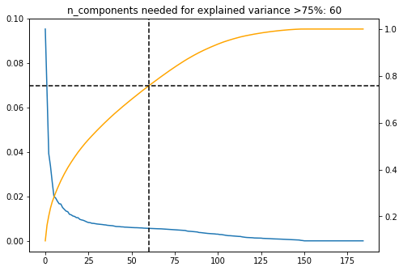

```python
# Investigate the variance accounted for by each principal component.
n_components = min(np.where(np.cumsum(pca.explained_variance_ratio_)>0.75)[0]+1)

fig = plt.figure()
ax = fig.add_axes([0,0,1,1],True)
ax2 = ax.twinx()
ax.plot(pca.explained_variance_ratio_, label = 'Variance')
ax2.plot(np.cumsum(pca.explained_variance_ratio_), label = 'Cumulative Variance', color = 'orange')
plt.axvline(x = n_components, ls = '--', color='black')
plt.axhline(y = np.cumsum(pca.explained_variance_ratio_)[n_components], ls = '--', color='black')
ax.set_title('n_components needed for explained variance >75%: {}'.format(n_components))
```

```python
# Re-apply PCA to the data while selecting for number of components to retain.
pca = PCA(n_components=n_components)
azdias_pca = pca.fit_transform(azdias_scaled)
```

```python
pca.explained_variance_ratio_.sum()
```

```
0.74835353931054927
```

### Step 2.3: Interpret Principal Components

Now that we have our transformed principal components, it's a nice idea to check out the weight of each variable on the first few components to see if they can be interpreted in some fashion.

As a reminder, each principal component is a unit vector that points in the direction of highest variance (after accounting for the variance captured by earlier principal components). The further a weight is from zero, the more the principal component is in the direction of the corresponding feature. If two features have large weights of the same sign (both positive or both negative), then increases in one tend expect to be associated with increases in the other. To contrast, features with different signs can be expected to show a negative correlation: increases in one variable should result in a decrease in the other.

- To investigate the features, you should map each weight to their corresponding feature name, then sort the features according to weight. The most interesting features for each principal component, then, will be those at the beginning and end of the sorted list. Use the data dictionary document to help you understand these most prominent features, their relationships, and what a positive or negative value on the principal component might indicate.
- You should investigate and interpret feature associations from the first three principal components in this substep. To help facilitate this, you should write a function that you can call at any time to print the sorted list of feature weights, for the *i*-th principal component. This might come in handy in the next step of the project, when you interpret the tendencies of the discovered clusters.

```python
# Map weights for the first principal component to corresponding feature names
# and then print the linked values, sorted by weight.
# HINT: Try defining a function here or in a new cell that you can reuse in the
# other cells.
def comp_analysis(df):
    feature_map = pd.Series(df.columns, range(len(df.columns)))
    components = {}
    for i in range(pca.components_.shape[0]):
        components[i] = [(feature_map[a],b) for a,b in sorted(enumerate(pca.components_[i]),key=lambda x:x[1],reverse=True)]
    return pd.DataFrame(components)
```

```python
# Top 5 positive features
components = comp_analysis(azdias)
components[:5]
```

|  | 0 | 1 | 2 | 3 | 4 | 5 | 6 | 7 | 8 | 9 | ... | 50 | 51 | 52 | 53 | 54 | 55 | 56 | 57 | 58 | 59 |
| --- | --- | --- | --- | --- | --- | --- | --- | --- | --- | --- | --- | --- | --- | --- | --- | --- | --- | --- | --- | --- | --- |
| 0 | (LP_STATUS_GROB_1.0, 0.183253075312) | (ALTERSKATEGORIE_GROB, 0.221652527526) | (SEMIO_VERT, 0.290784946566) | (GREEN_AVANTGARDE, 0.232538987795) | (ANZ_PERSONEN, 0.277011639201) | (LP_FAMILIE_GROB_4.0, 0.233591079138) | (LP_FAMILIE_GROB_5.0, 0.334171000819) | (LP_STATUS_GROB_2.0, 0.318934813527) | (LP_FAMILIE_GROB_3.0, 0.491047366111) | (LP_STATUS_GROB_3.0, 0.34128844132) | ... | (GFK_URLAUBERTYP_10.0, 0.519435268364) | (GFK_URLAUBERTYP_11.0, 0.267951848839) | (LP_FAMILIE_FEIN_5.0, 0.258150139371) | (CAMEO_DEUG_2015_1, 0.258018285208) | (SOHO_KZ, 0.329690973146) | (GFK_URLAUBERTYP_4.0, 0.211902469208) | (LP_LEBENSPHASE_GROB_10.0, 0.33942451489) | (NATIONALITAET_KZ_3.0, 0.263547062433) | (GFK_URLAUBERTYP_3.0, 0.197461873099) | (GFK_URLAUBERTYP_4.0, 0.275725090565) |
| 1 | (HH_EINKOMMEN_SCORE, 0.171325080883) | (FINANZ_VORSORGER, 0.205644353007) | (SEMIO_SOZ, 0.236925805028) | (PRAEGENDE_JUGENDJAHRE_MOVEMENT_0, 0.232538987... | (LP_FAMILIE_GROB_5.0, 0.258409196278) | (LP_LEBENSPHASE_GROB_8.0, 0.227380914875) | (LP_FAMILIE_FEIN_10.0, 0.263459287426) | (LP_FAMILIE_GROB_4.0, 0.234916643399) | (LP_LEBENSPHASE_GROB_6.0, 0.491047366111) | (GEBAEUDETYP_3.0, 0.331442509414) | ... | (FINANZTYP_4, 0.21709191957) | (LP_FAMILIE_FEIN_4.0, 0.249795092768) | (LP_FAMILIE_FEIN_6.0, 0.251255796437) | (LP_FAMILIE_FEIN_4.0, 0.22771051117) | (GFK_URLAUBERTYP_4.0, 0.248881460927) | (PRAEGENDE_JUGENDJAHRE_DECADE_40, 0.203001355431) | (LP_FAMILIE_FEIN_9.0, 0.307318464993) | (WOHNLAGE_0.0, 0.260919718059) | (GFK_URLAUBERTYP_12.0, 0.169747729061) | (GFK_URLAUBERTYP_1.0, 0.252779053542) |
| 2 | (PLZ8_ANTG3, 0.170738487282) | (ZABEOTYP_3, 0.192081937823) | (SEMIO_FAM, 0.236747734228) | (SEMIO_KAEM, 0.191260344315) | (LP_FAMILIE_FEIN_10.0, 0.201737601057) | (PRAEGENDE_JUGENDJAHRE_DECADE_80, 0.177981766359) | (LP_LEBENSPHASE_GROB_12.0, 0.186310128282) | (LP_STATUS_FEIN_3.0, 0.21947407341) | (LP_FAMILIE_FEIN_4.0, 0.318601825123) | (LP_STATUS_FEIN_6.0, 0.298730548593) | ... | (WOHNLAGE_4.0, 0.210928866155) | (GFK_URLAUBERTYP_5.0, 0.235965897793) | (GFK_URLAUBERTYP_4.0, 0.238958331611) | (PLZ8_BAUMAX_2.0, 0.215523496649) | (LP_FAMILIE_FEIN_9.0, 0.243430090169) | (GFK_URLAUBERTYP_9.0, 0.185506919382) | (GFK_URLAUBERTYP_1.0, 0.22985583724) | (LP_FAMILIE_FEIN_3.0, 0.236961967257) | (GFK_URLAUBERTYP_6.0, 0.166790154002) | (WOHNLAGE_0.0, 0.216241579741) |
| 3 | (PLZ8_ANTG4, 0.16538121932) | (SEMIO_ERL, 0.171527476309) | (SEMIO_KULT, 0.223972392747) | (SEMIO_DOM, 0.18870730073) | (LP_LEBENSPHASE_GROB_10.0, 0.15910094881) | (FINANZTYP_6, 0.17197340089) | (LP_FAMILIE_FEIN_11.0, 0.153654368592) | (LP_LEBENSPHASE_GROB_7.0, 0.195593827696) | (LP_FAMILIE_FEIN_5.0, 0.310016066178) | (PLZ8_BAUMAX_5.0, 0.181842307194) | ... | (WOHNLAGE_2.0, 0.185234126176) | (PRAEGENDE_JUGENDJAHRE_DECADE_50, 0.179615453652) | (PRAEGENDE_JUGENDJAHRE_DECADE_40, 0.210508645904) | (GEBAEUDETYP_5.0, 0.20644051121) | (GFK_URLAUBERTYP_9.0, 0.215813375732) | (CJT_GESAMTTYP_6.0, 0.176394657654) | (LP_LEBENSPHASE_GROB_5.0, 0.221097467303) | (GEBAEUDETYP_5.0, 0.206351031813) | (WOHNLAGE_2.0, 0.16659934846) | (GFK_URLAUBERTYP_9.0, 0.202200519129) |
| 4 | (ORTSGR_KLS9, 0.143498336328) | (RETOURTYP_BK_S, 0.154993031385) | (GREEN_AVANTGARDE, 0.14372748826) | (LP_STATUS_FEIN_10.0, 0.187354682187) | (KKK, 0.151096378209) | (LP_LEBENSPHASE_GROB_3.0, 0.159577528317) | (LP_LEBENSPHASE_GROB_9.0, 0.153164879801) | (LP_STATUS_FEIN_4.0, 0.187693948646) | (LP_FAMILIE_FEIN_3.0, 0.195432675921) | (LP_STATUS_FEIN_7.0, 0.158669972987) | ... | (GFK_URLAUBERTYP_12.0, 0.119787480827) | (FINANZTYP_3, 0.128285279458) | (GFK_URLAUBERTYP_5.0, 0.192190579658) | (WOHNLAGE_0.0, 0.193591222564) | (LP_LEBENSPHASE_GROB_9.0, 0.183263049788) | (FINANZTYP_6, 0.157744760989) | (LP_FAMILIE_FEIN_11.0, 0.197664628263) | (GFK_URLAUBERTYP_1.0, 0.205905757183) | (GFK_URLAUBERTYP_4.0, 0.145149550767) | (LP_FAMILIE_FEIN_4.0, 0.171185885097) |

5 rows × 60 columns

```python
# Top 10 negative features
components[-5:]
```

|  | 0 | 1 | 2 | 3 | 4 | 5 | 6 | 7 | 8 | 9 | ... | 50 | 51 | 52 | 53 | 54 | 55 | 56 | 57 | 58 | 59 |
| --- | --- | --- | --- | --- | --- | --- | --- | --- | --- | --- | --- | --- | --- | --- | --- | --- | --- | --- | --- | --- | --- |
| 180 | (KBA05_GBZ, -0.170300300842) | (SEMIO_TRADV, -0.197812336192) | (SEMIO_ERL, -0.190866782011) | (WOHNLAGE_7.0, -0.15873476474) | (LP_LEBENSPHASE_GROB_1.0, -0.179449523232) | (LP_LEBENSPHASE_GROB_4.0, -0.220970930603) | (LP_FAMILIE_GROB_4.0, -0.186699616572) | (W_KEIT_KIND_HH, -0.13108645885) | (LP_FAMILIE_FEIN_7.0, -0.162760083289) | (PLZ8_ANTG2, -0.121204069797) | ... | (WOHNLAGE_1.0, -0.171113521116) | (LP_FAMILIE_FEIN_3.0, -0.185200021649) | (LP_FAMILIE_FEIN_4.0, -0.158324468838) | (GFK_URLAUBERTYP_11.0, -0.147180206363) | (GFK_URLAUBERTYP_1.0, -0.150354235496) | (NATIONALITAET_KZ_3.0, -0.184666924892) | (GFK_URLAUBERTYP_4.0, -0.172567525901) | (LP_LEBENSPHASE_GROB_10.0, -0.127665126671) | (WOHNLAGE_1.0, -0.194577700478) | (ZABEOTYP_1, -0.192051707489) |
| 181 | (PLZ8_ANTG1, -0.172925157892) | (SEMIO_PFLICHT, -0.201287841846) | (SEMIO_DOM, -0.237726991689) | (LP_FAMILIE_FEIN_1.0, -0.16259240646) | (LP_LEBENSPHASE_GROB_3.0, -0.180148037911) | (FINANZ_HAUSBAUER, -0.221276026435) | (LP_LEBENSPHASE_GROB_5.0, -0.254074682757) | (LP_STATUS_FEIN_9.0, -0.133158041645) | (LP_LEBENSPHASE_GROB_8.0, -0.181362088545) | (KBA05_ANTG3, -0.122048542185) | ... | (GFK_URLAUBERTYP_1.0, -0.22341336061) | (FINANZTYP_4, -0.19071867161) | (FINANZTYP_4, -0.162362917904) | (PRAEGENDE_JUGENDJAHRE_DECADE_50, -0.160579069... | (LP_LEBENSPHASE_GROB_11.0, -0.153826468276) | (GFK_URLAUBERTYP_5.0, -0.18606503104) | (GFK_URLAUBERTYP_8.0, -0.184832886149) | (CJT_GESAMTTYP_6.0, -0.180907664817) | (LP_FAMILIE_FEIN_6.0, -0.201699693785) | (LP_FAMILIE_FEIN_7.0, -0.202812860492) |
| 182 | (KBA05_ANTG1, -0.181054574953) | (FINANZ_UNAUFFAELLIGER, -0.205549066195) | (SEMIO_KRIT, -0.240219414128) | (LP_FAMILIE_GROB_1.0, -0.16259240646) | (W_KEIT_KIND_HH, -0.196838985092) | (LP_STATUS_GROB_2.0, -0.222514678945) | (LP_LEBENSPHASE_GROB_4.0, -0.260715371617) | (LP_STATUS_GROB_4.0, -0.140199687962) | (LP_FAMILIE_FEIN_8.0, -0.184516800774) | (KBA05_ANTG2, -0.130102548479) | ... | (GFK_URLAUBERTYP_3.0, -0.224235609488) | (GFK_URLAUBERTYP_8.0, -0.2030080924) | (GFK_URLAUBERTYP_1.0, -0.180171477641) | (LP_FAMILIE_FEIN_3.0, -0.160617777706) | (LP_FAMILIE_FEIN_8.0, -0.157905501369) | (GFK_URLAUBERTYP_6.0, -0.192909262821) | (LP_LEBENSPHASE_GROB_4.0, -0.199982510832) | (NATIONALITAET_KZ_2.0, -0.182334532905) | (PLZ8_BAUMAX_3.0, -0.218963462086) | (GFK_URLAUBERTYP_2.0, -0.207960742241) |
| 183 | (FINANZ_MINIMALIST, -0.181477687942) | (SEMIO_REL, -0.206166218103) | (SEMIO_KAEM, -0.272454015919) | (LP_STATUS_GROB_4.0, -0.166131563707) | (LP_FAMILIE_FEIN_1.0, -0.32827604245) | (LP_FAMILIE_FEIN_2.0, -0.245958935549) | (LP_FAMILIE_FEIN_2.0, -0.377256325783) | (KKK, -0.144304021727) | (LP_LEBENSPHASE_GROB_7.0, -0.203062184987) | (GEBAEUDETYP_RASTER, -0.253358685933) | ... | (GFK_URLAUBERTYP_11.0, -0.258516026658) | (GFK_URLAUBERTYP_12.0, -0.221310025003) | (GFK_URLAUBERTYP_8.0, -0.251746565504) | (CAMEO_DEUG_2015_3, -0.166908173302) | (LP_LEBENSPHASE_GROB_7.0, -0.163720269688) | (PRAEGENDE_JUGENDJAHRE_DECADE_50, -0.214391064... | (LP_FAMILIE_FEIN_10.0, -0.213210581321) | (GFK_URLAUBERTYP_6.0, -0.347688388264) | (GFK_URLAUBERTYP_1.0, -0.297602925386) | (LP_FAMILIE_FEIN_3.0, -0.227876795269) |
| 184 | (MOBI_REGIO, -0.192063311691) | (FINANZ_SPARER, -0.214415467281) | (ANREDE_KZ, -0.305568171356) | (PRAEGENDE_JUGENDJAHRE_MOVEMENT_1, -0.23253898... | (LP_FAMILIE_GROB_1.0, -0.32827604245) | (LP_FAMILIE_GROB_2.0, -0.245958935549) | (LP_FAMILIE_GROB_2.0, -0.377256325783) | (LP_LEBENSPHASE_GROB_5.0, -0.153954092898) | (LP_FAMILIE_GROB_4.0, -0.275486616711) | (GEBAEUDETYP_1.0, -0.283534957049) | ... | (WOHNLAGE_5.0, -0.270336066903) | (PRAEGENDE_JUGENDJAHRE_DECADE_40, -0.338868617... | (PRAEGENDE_JUGENDJAHRE_DECADE_50, -0.297975032... | (GFK_URLAUBERTYP_3.0, -0.185531104078) | (GFK_URLAUBERTYP_5.0, -0.191521724403) | (LP_FAMILIE_FEIN_9.0, -0.288951067294) | (SOHO_KZ, -0.274845366956) | (LP_FAMILIE_FEIN_9.0, -0.375146803575) | (LP_FAMILIE_FEIN_9.0, -0.428372687266) | (GFK_URLAUBERTYP_8.0, -0.257711872249) |

5 rows × 60 columns

```python
# Map weights for the first three principal components to corresponding feature names and then print the linked values, sorted by weight.
def comp(components,compnum):
    print('Top 5 positive corresponding features and weights for Component {}: \n\n'.format(compnum), components.loc[:4,compnum])
    print('Top 5 negative corresponding features and weights for Component {}: \n\n'.format(compnum), components.loc[components.shape[0]-5:,compnum])

for num in range(3):
    comp(components,num)
```

```
Top 5 positive corresponding features and weights for Component 0:

 0    (LP_STATUS_GROB_1.0, 0.183253075312)
1    (HH_EINKOMMEN_SCORE, 0.171325080883)
2            (PLZ8_ANTG3, 0.170738487282)
3             (PLZ8_ANTG4, 0.16538121932)
4           (ORTSGR_KLS9, 0.143498336328)
Name: 0, dtype: object
Top 5 negative corresponding features and weights for Component 0:

 180            (KBA05_GBZ, -0.170300300842)
181           (PLZ8_ANTG1, -0.172925157892)
182          (KBA05_ANTG1, -0.181054574953)
183    (FINANZ_MINIMALIST, -0.181477687942)
184           (MOBI_REGIO, -0.192063311691)
Name: 0, dtype: object
Top 5 positive corresponding features and weights for Component 1:

 0    (ALTERSKATEGORIE_GROB, 0.221652527526)
1        (FINANZ_VORSORGER, 0.205644353007)
2              (ZABEOTYP_3, 0.192081937823)
3               (SEMIO_ERL, 0.171527476309)
4          (RETOURTYP_BK_S, 0.154993031385)
Name: 1, dtype: object
Top 5 negative corresponding features and weights for Component 1:

 180              (SEMIO_TRADV, -0.197812336192)
181            (SEMIO_PFLICHT, -0.201287841846)
182    (FINANZ_UNAUFFAELLIGER, -0.205549066195)
183                (SEMIO_REL, -0.206166218103)
184            (FINANZ_SPARER, -0.214415467281)
Name: 1, dtype: object
Top 5 positive corresponding features and weights for Component 2:

 0         (SEMIO_VERT, 0.290784946566)
1          (SEMIO_SOZ, 0.236925805028)
2          (SEMIO_FAM, 0.236747734228)
3         (SEMIO_KULT, 0.223972392747)
4    (GREEN_AVANTGARDE, 0.14372748826)
Name: 2, dtype: object
Top 5 negative corresponding features and weights for Component 2:

 180     (SEMIO_ERL, -0.190866782011)
181     (SEMIO_DOM, -0.237726991689)
182    (SEMIO_KRIT, -0.240219414128)
183    (SEMIO_KAEM, -0.272454015919)
184     (ANREDE_KZ, -0.305568171356)
Name: 2, dtype: object
```

### Discussion 2.3: Interpret Principal Components

Here are the top 5 positively and negatively corresponding feature names to the first three components based on the Data Dictionary:

#### Component 0:

##### Positive Top 5

```
            LP_STATUS_GROB_1.0 -- Rough scale social status as low-income earners
            HH_EINKOMMEN_SCORE -- Estimated household net income
            PLZ8_ANTG3 -- Number of 6-10 family houses in the PLZ8 region
            PLZ8_ANTG4 -- Number of 10+ family houses in the PLZ8 region
            ORTSGR_KLS9 -- Size of community
```

##### Negative Top 5

```
            KBA05_GBZ -- Number of buildings in the microcell
            PLZ8_ANTG1 -- Number of 1-2 family houses in the PLZ8 region
            KBA05_ANTG1 -- Number of 1-2 family houses in the microcell
            FINANZ_MINIMALIST -- Degree of Financial type - low financial interest
            MOBI_REGIO -- Movement patterns
```

#### Component 1:

##### Positive Top 5

```
            ALTERSKATEGORIE_GROB -- Estimated age based on given name analysis
            FINANZ_VORSORGER -- Degree of Financial type - be prepared
            ZABEOTYP_3 -- Energy consumption type - fair supplied
            SEMIO_ERL -- Degree of Personality - event-oriented
            RETOURTYP_BK_S -- Shopping return type
```

##### Negative Top 5

```
            SEMIO_TRADV -- Degree of Personality - tradional-minded
            SEMIO_PFLICHT -- Degree of Personality - dutiful
            FINANZ_UNAUFFAELLIGER -- Degree of Financial type - inconspicuous
            SEMIO_REL -- Degree of Personality - religious
            FINANZ_SPARER -- Degree of Financial type - money-saver
```

#### Component 2:

##### Positive Top 5

```
            SEMIO_VERT -- Degree of Personality - dreamful
            SEMIO_SOZ -- Degree of Personality - socially-minded
            SEMIO_FAM -- Degree of Personality - family-minded
            SEMIO_KULT -- Degree of Personality - cultural-minded
            GREEN_AVANTGARDE --  Membership in environmental sustainability as part of youth
```

##### Negative Top 5

```
            SEMIO_ERL -- Degree of Personality - event-oriented
            SEMIO_DOM -- Degree of Personality - dominant-minded
            SEMIO_KRIT -- Degree of Personality - critical-minded
            SEMIO_KAEM -- Degree of Personality - combative attitude
            ANREDE_KZ -- Gender
```

## Step 3: Clustering

### Step 3.1: Apply Clustering to General Population

You've assessed and cleaned the demographics data, then scaled and transformed them. Now, it's time to see how the data clusters in the principal components space. In this substep, you will apply k-means clustering to the dataset and use the average within-cluster distances from each point to their assigned cluster's centroid to decide on a number of clusters to keep.

- Use sklearn's KMeans class to perform k-means clustering on the PCA-transformed data.
- Then, compute the average difference from each point to its assigned cluster's center. **Hint**: The KMeans object's `.score()` method might be useful here, but note that in sklearn, scores tend to be defined so that larger is better. Try applying it to a small, toy dataset, or use an internet search to help your understanding.
- Perform the above two steps for a number of different cluster counts. You can then see how the average distance decreases with an increasing number of clusters. However, each additional cluster provides a smaller net benefit. Use this fact to select a final number of clusters in which to group the data. **Warning**: because of the large size of the dataset, it can take a long time for the algorithm to resolve. The more clusters to fit, the longer the algorithm will take. You should test for cluster counts through at least 10 clusters to get the full picture, but you shouldn't need to test for a number of clusters above about 30.
- Once you've selected a final number of clusters to use, re-fit a KMeans instance to perform the clustering operation. Make sure that you also obtain the cluster assignments for the general demographics data, since you'll be using them in the final Step 3.3.

```python
# Over a number of different cluster counts...
    # run k-means clustering on the data and...
    # compute the average within-cluster distances.
sse = [] # Sum of Squared Errors
for k in range(2,30,1):
    kmeans = MiniBatchKMeans(k).fit(azdias_pca)
    score = np.abs(kmeans.score(azdias_pca))
    sse.append(score)
    print('Clustering done for {} k, with SSE {}'.format(k, score))
```

```
Clustering done for 2 k, with SSE 79083793.9027811
Clustering done for 3 k, with SSE 73828237.71625784
Clustering done for 4 k, with SSE 71462559.59562036
Clustering done for 5 k, with SSE 69898423.44419897
Clustering done for 6 k, with SSE 68704886.0449605
Clustering done for 7 k, with SSE 66311685.36377126
Clustering done for 8 k, with SSE 65004231.45597763
Clustering done for 9 k, with SSE 64958724.186206646
Clustering done for 10 k, with SSE 63863785.81939615
Clustering done for 11 k, with SSE 65154773.0886877
Clustering done for 12 k, with SSE 61693029.1752549
Clustering done for 13 k, with SSE 62118789.68375666
Clustering done for 14 k, with SSE 60635850.06530581
Clustering done for 15 k, with SSE 60428257.155198134
Clustering done for 16 k, with SSE 58927439.11352095
Clustering done for 17 k, with SSE 57590135.65823101
Clustering done for 18 k, with SSE 57368600.48660731
Clustering done for 19 k, with SSE 57706599.56004396
Clustering done for 20 k, with SSE 59094779.10158827
Clustering done for 21 k, with SSE 56338646.85911689
Clustering done for 22 k, with SSE 55394474.98116637
Clustering done for 23 k, with SSE 56431844.72581729
Clustering done for 24 k, with SSE 54840243.883756556
Clustering done for 25 k, with SSE 54395800.37364222
Clustering done for 26 k, with SSE 53871885.20782198
Clustering done for 27 k, with SSE 56579631.49548925
Clustering done for 28 k, with SSE 53129354.280249044
Clustering done for 29 k, with SSE 52655440.87438
```

```
Text(0.5,1,'Sum of squared errors with number of clusters')
```

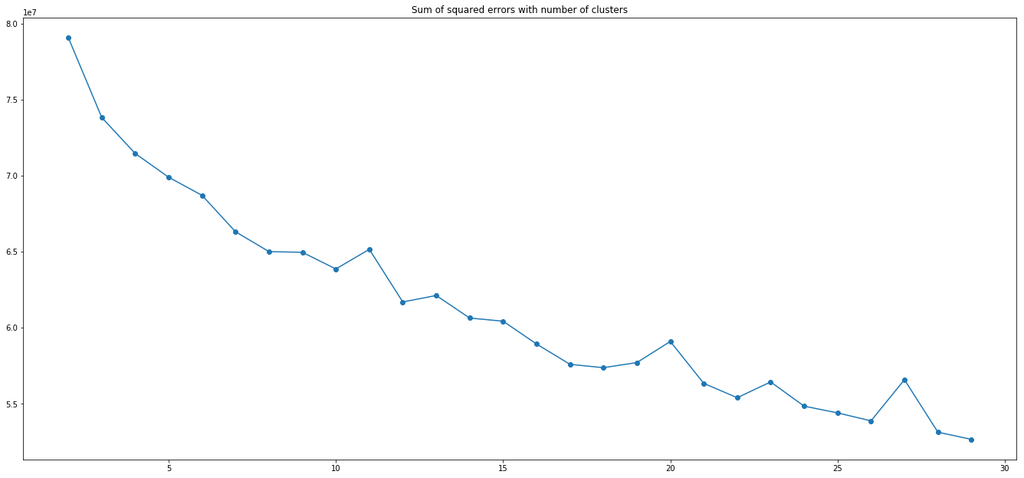

```python
# Investigate the change in within-cluster distance across number of clusters.
# HINT: Use matplotlib's plot function to visualize this relationship.
k_range = np.arange(2,30,1)

fig = plt.figure(figsize=(18, 8))
ax = fig.add_axes([0,0,1,1],True)
ax.plot(k_range, sse, linestyle='-', marker='o')
ax.set_title('Sum of squared errors with number of clusters')
```

```python
# Re-fit the k-means model with the selected number of clusters and obtain
# cluster predictions for the general population demographics data.
kmeans = KMeans(22, random_state=10)
clusters_pop = kmeans.fit_predict(azdias_pca)
```

### Discussion 3.1: Apply Clustering to General Population

When testing kmeans with different number of clusters ranging from 2 to 30 is time-consuming. Thus, I applied MiniBatchKmeans to reduce the running time. Based on the figure, the marginal decrease in distance is diminishing around 15-20. Thus, I chose 22 clusters to apply to the general population clustering.

### Step 3.2: Apply All Steps to the Customer Data

Now that you have clusters and cluster centers for the general population, it's time to see how the customer data maps on to those clusters. Take care to not confuse this for re-fitting all of the models to the customer data. Instead, you're going to use the fits from the general population to clean, transform, and cluster the customer data. In the last step of the project, you will interpret how the general population fits apply to the customer data.

- Don't forget when loading in the customers data, that it is semicolon (`;`) delimited.
- Apply the same feature wrangling, selection, and engineering steps to the customer demographics using the `clean_data()` function you created earlier. (You can assume that the customer demographics data has similar meaning behind missing data patterns as the general demographics data.)
- Use the sklearn objects from the general demographics data, and apply their transformations to the customers data. That is, you should not be using a `.fit()` or `.fit_transform()` method to re-fit the old objects, nor should you be creating new sklearn objects! Carry the data through the feature scaling, PCA, and clustering steps, obtaining cluster assignments for all of the data in the customer demographics data.

```python
# Load in the customer demographics data.
customers = pd.read_csv('Udacity_CUSTOMERS_Subset.csv', sep = ';')
```

```python
cus = clean_data(customers)
```

```python
cus.columns
```

```
Index(['ALTERSKATEGORIE_GROB', 'ANREDE_KZ', 'FINANZ_MINIMALIST',
       'FINANZ_SPARER', 'FINANZ_VORSORGER', 'FINANZ_ANLEGER',
       'FINANZ_UNAUFFAELLIGER', 'FINANZ_HAUSBAUER', 'GREEN_AVANTGARDE',
       'HEALTH_TYP',
       ...
       'CAMEO_INTL_2015_WEALTH_1', 'CAMEO_INTL_2015_WEALTH_2',
       'CAMEO_INTL_2015_WEALTH_3', 'CAMEO_INTL_2015_WEALTH_4',
       'CAMEO_INTL_2015_WEALTH_5', 'CAMEO_INTL_2015_LIFESTAGE_1',
       'CAMEO_INTL_2015_LIFESTAGE_2', 'CAMEO_INTL_2015_LIFESTAGE_3',
       'CAMEO_INTL_2015_LIFESTAGE_4', 'CAMEO_INTL_2015_LIFESTAGE_5'],
      dtype='object', length=182)
```

```python
missing_col = azdias.columns.difference(cus.columns)
print (missing_col)
```

```
Index(['GEBAEUDETYP_5.0', 'WOHNLAGE_0.0', 'num_missing'], dtype='object')
```

```python
for col in missing_col:
    cus[col] = 0
```

```python
cus.shape
```

```
(115643, 185)
```

```python
cus_scaled = scaler.fit_transform(cus)
```

```python
# Apply the fitted pca and kmeans on the scaled customer data
cus_pca = pca.fit_transform(cus_scaled)
clusters_cus = kmeans.fit_predict(cus_pca)
```

### Step 3.3: Compare Customer Data to Demographics Data

At this point, you have clustered data based on demographics of the general population of Germany, and seen how the customer data for a mail-order sales company maps onto those demographic clusters. In this final substep, you will compare the two cluster distributions to see where the strongest customer base for the company is.

Consider the proportion of persons in each cluster for the general population, and the proportions for the customers. If we think the company's customer base to be universal, then the cluster assignment proportions should be fairly similar between the two. If there are only particular segments of the population that are interested in the company's products, then we should see a mismatch from one to the other. If there is a higher proportion of persons in a cluster for the customer data compared to the general population (e.g. 5% of persons are assigned to a cluster for the general population, but 15% of the customer data is closest to that cluster's centroid) then that suggests the people in that cluster to be a target audience for the company. On the other hand, the proportion of the data in a cluster being larger in the general population than the customer data (e.g. only 2% of customers closest to a population centroid that captures 6% of the data) suggests that group of persons to be outside of the target demographics.

Take a look at the following points in this step:

- Compute the proportion of data points in each cluster for the general population and the customer data. Visualizations will be useful here: both for the individual dataset proportions, but also to visualize the ratios in cluster representation between groups. Seaborn's [`countplot()`](https://seaborn.pydata.org/generated/seaborn.countplot.html) or [`barplot()`](https://seaborn.pydata.org/generated/seaborn.barplot.html) function could be handy.
  - Recall the analysis you performed in step 1.1.3 of the project, where you separated out certain data points from the dataset if they had more than a specified threshold of missing values. If you found that this group was qualitatively different from the main bulk of the data, you should treat this as an additional data cluster in this analysis. Make sure that you account for the number of data points in this subset, for both the general population and customer datasets, when making your computations!
- Which cluster or clusters are overrepresented in the customer dataset compared to the general population? Select at least one such cluster and infer what kind of people might be represented by that cluster. Use the principal component interpretations from step 2.3 or look at additional components to help you make this inference. Alternatively, you can use the `.inverse_transform()` method of the PCA and StandardScaler objects to transform centroids back to the original data space and interpret the retrieved values directly.
- Perform a similar investigation for the underrepresented clusters. Which cluster or clusters are underrepresented in the customer dataset compared to the general population, and what kinds of people are typified by these clusters?

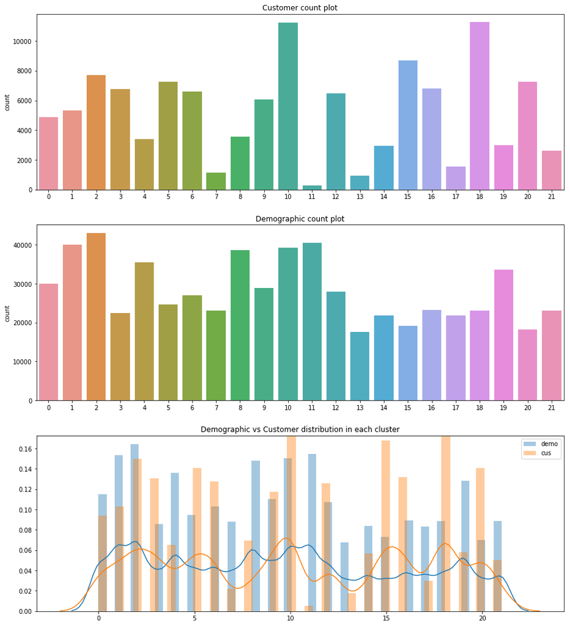

```python
# Compare the proportion of data in each cluster for the customer data to the
# proportion of data in each cluster for the general population.
fig = plt.figure()
ax=fig.add_axes([0,0,2,1], title='Demographic vs Customer distribution in each cluster')
ax2=fig.add_axes([0,1.2,2,1], title='Demographic count plot')
ax3=fig.add_axes([0,2.4,2,1], title='Customer count plot')

sns.distplot(clusters_pop, label='demo',ax=ax)
sns.distplot(clusters_cus, label='cus', ax=ax)
sns.countplot(clusters_pop, label='demo', ax=ax2)
sns.countplot(clusters_cus, label='cus', ax=ax3)
ax.legend();
```

```python
# Compare the proportion of data in each cluster for the customer data to the
# proportion of data in each cluster for the general population.

cus_df = pd.DataFrame(clusters_cus,columns=['Cluster']).reset_index().groupby('Cluster').count()/len(clusters_cus)*100
pop_df = pd.DataFrame(clusters_pop,columns=['Cluster']).reset_index().groupby('Cluster').count()/len(clusters_pop)*100
diff_df = (cus_df-pop_df)
cus_df.rename_axis({'index':'Cus%'}, axis=1, inplace=True)
pop_df.rename_axis({'index':'Pop%'}, axis=1, inplace=True)
diff_df.rename_axis({'index':'Diff%'}, axis=1, inplace=True)
summary = diff_df.join(cus_df).join(pop_df).sort_values(by = 'Diff%', ascending = False)
summary
```

| Cluster | Diff% | Cus% | Pop% |
| --- | --- | --- | --- |
| 18 | 6.031480 | 9.742916 | 3.711435 |
| 15 | 4.431252 | 7.507588 | 3.076336 |
| 10 | 3.422038 | 9.733404 | 6.311366 |
| 20 | 3.348587 | 6.277942 | 2.929354 |
| 5 | 2.310189 | 6.277077 | 3.966888 |
| 3 | 2.232931 | 5.840388 | 3.607458 |
| 16 | 2.152827 | 5.888813 | 3.735986 |
| 6 | 1.367958 | 5.696843 | 4.328885 |
| 12 | 1.115570 | 5.610370 | 4.494800 |
| 9 | 0.603057 | 5.232483 | 4.629426 |
| 2 | -0.226853 | 6.679176 | 6.906030 |
| 0 | -0.613550 | 4.203454 | 4.817004 |
| 14 | -0.983575 | 2.527607 | 3.511182 |
| 21 | -1.467942 | 2.243975 | 3.711917 |
| 1 | -1.842757 | 4.593447 | 6.436204 |
| 13 | -2.029031 | 0.799875 | 2.828907 |
| 17 | -2.184258 | 1.321308 | 3.505566 |
| 7 | -2.712994 | 0.983198 | 3.696192 |
| 4 | -2.774952 | 2.925382 | 5.700335 |
| 19 | -2.798739 | 2.595920 | 5.394659 |
| 8 | -3.114890 | 3.093140 | 6.208030 |
| 11 | -6.266349 | 0.225695 | 6.492044 |

```python
cluster_specs = pd.DataFrame(scaler.inverse_transform(pca.inverse_transform(kmeans.cluster_centers_)), columns=azdias.columns)
cluster_specs.sort_values(by = 18, axis = 1, ascending = False)
```

|  | MIN_GEBAEUDEJAHR | KBA13_ANZAHL_PKW | WOHNDAUER_2008 | INNENSTADT | BALLRAUM | SEMIO_LUST | SEMIO_VERT | SEMIO_ERL | FINANZ_MINIMALIST | FINANZ_VORSORGER | ... | CAMEO_DEUG_2015_8 | FINANZTYP_2 | LP_FAMILIE_FEIN_2.0 | ANZ_TITEL | CJT_GESAMTTYP_6.0 | LP_STATUS_FEIN_2.0 | PLZ8_BAUMAX_1.0 | KBA05_ANTG3 | ANZ_HH_TITEL | CAMEO_DEUG_2015_9 |
| --- | --- | --- | --- | --- | --- | --- | --- | --- | --- | --- | --- | --- | --- | --- | --- | --- | --- | --- | --- | --- | --- |
| 0 | 1992.335273 | 647.755500 | 8.872565 | 4.193260 | 3.792303 | 5.942879 | 6.002973 | 4.117116 | 4.660384 | 4.835213 | ... | 0.000030 | -0.009306 | -0.001362 | 0.430576 | 0.010868 | -0.001132 | 0.025057 | 0.263911 | 0.593671 | -0.022014 |
| 1 | 1992.567086 | 704.323320 | 8.890799 | 5.774523 | 5.232358 | 5.441792 | 5.291828 | 4.824739 | 4.835170 | 4.781882 | ... | -0.009374 | 0.011916 | 0.001694 | 0.003897 | -0.004894 | 0.000010 | -0.005907 | 0.032930 | -0.008031 | -0.020453 |
| 2 | 1992.279235 | 554.585499 | 8.498110 | 3.577406 | 3.313835 | 5.521621 | 5.977724 | 4.234234 | 3.178029 | 4.693056 | ... | 0.010785 | 0.006879 | 0.000606 | 0.005124 | 0.034517 | 0.010362 | 0.140775 | 1.189385 | 0.078200 | 0.384692 |
| 3 | 1992.458409 | 682.234425 | 8.858394 | 4.888294 | 4.348095 | 5.730548 | 3.287325 | 6.583041 | 4.440223 | 4.766341 | ... | -0.007069 | -0.001145 | -0.002977 | 0.017186 | 0.017646 | 0.016614 | -0.002013 | 0.010897 | -0.005884 | 0.008092 |
| 4 | 1992.143264 | 582.711469 | 8.999633 | 3.428720 | 2.763261 | 5.758170 | 5.212153 | 4.805122 | 3.574925 | 4.822940 | ... | 0.003203 | 0.025606 | 0.007130 | 0.004879 | 0.019550 | 0.819217 | 0.096793 | 0.957137 | 0.115930 | 0.062276 |
| 5 | 1992.444968 | 699.993361 | 8.853096 | 4.776812 | 4.221208 | 4.643721 | 5.842208 | 3.907453 | 4.942674 | 4.625191 | ... | 0.002602 | 0.009342 | -0.002770 | -0.006094 | -0.006705 | 0.005958 | 0.017333 | -0.000079 | -0.014495 | -0.017491 |
| 6 | 1992.399729 | 678.060113 | 8.850626 | 4.497710 | 3.895272 | 6.082623 | 6.359069 | 3.982652 | 4.956274 | 4.825977 | ... | 0.014507 | 0.010612 | 0.002484 | 0.011391 | -0.005635 | 0.016803 | 0.027790 | 0.063599 | 0.005851 | 0.073469 |
| 7 | 1992.835209 | 648.478060 | 8.529900 | 4.714915 | 4.175308 | 4.802192 | 4.507287 | 4.841089 | 3.766266 | 3.700181 | ... | -0.003436 | 0.055389 | 0.096338 | 0.009248 | 0.110348 | 0.070558 | 0.035119 | 0.349625 | 0.053081 | 0.006604 |
| 8 | 1992.300941 | 807.867701 | 8.593505 | 6.457298 | 6.007940 | 5.923608 | 4.363888 | 6.031900 | 3.321290 | 4.732168 | ... | 0.022308 | -0.028541 | 0.002536 | -0.004056 | 0.002780 | 0.409783 | 0.022846 | 0.668593 | 0.030749 | 0.524529 |
| 9 | 1992.353157 | 677.660700 | 8.835177 | 4.682559 | 4.062632 | 5.897071 | 3.218545 | 6.640824 | 4.441823 | 4.823531 | ... | -0.001587 | 0.011118 | -0.000022 | 0.015278 | 0.018007 | 0.028244 | 0.013328 | 0.047677 | 0.005207 | 0.073492 |
| 10 | 1992.378013 | 699.416620 | 8.924497 | 4.845631 | 4.321170 | 6.536255 | 6.634165 | 4.198559 | 5.015821 | 4.935395 | ... | 0.001079 | -0.005300 | -0.000970 | -0.008606 | -0.004232 | 0.009228 | 0.003758 | 0.009128 | -0.013961 | -0.014340 |
| 11 | 1989.777224 | 710.389523 | 6.307948 | 3.122810 | 2.134197 | 6.670528 | 4.286480 | 5.531839 | 2.596192 | 4.899023 | ... | 0.006323 | 0.072892 | 0.004105 | 0.521852 | 0.000070 | 0.447728 | 0.002782 | -1.251108 | 5.503644 | 0.539095 |
| 12 | 1992.603391 | 704.670272 | 8.607892 | 5.754062 | 5.288712 | 5.528004 | 4.891808 | 5.251530 | 4.765285 | 4.747404 | ... | 0.013824 | 0.017138 | 0.001420 | 0.002379 | -0.001983 | 0.010909 | 0.011264 | 0.023559 | -0.008569 | 0.074735 |
| 13 | 1992.688912 | 656.172544 | 8.706072 | 4.871802 | 4.369610 | 4.080378 | 4.415586 | 4.018971 | 1.952997 | 2.340443 | ... | -0.007769 | -0.039372 | 0.009375 | -0.012176 | 0.600893 | 0.192215 | 0.008409 | 0.185108 | -0.040492 | 0.093085 |
| 14 | 1992.629939 | 695.650378 | 8.488004 | 5.591144 | 4.997763 | 4.375738 | 5.207969 | 4.055125 | 4.134523 | 2.113228 | ... | 0.023251 | 0.494477 | 0.003798 | 0.028645 | -0.001556 | 0.031128 | 0.021113 | 0.143674 | 0.041038 | -0.030877 |
| 15 | 1992.332200 | 687.809461 | 8.931348 | 4.621014 | 3.996678 | 6.043464 | 6.308101 | 4.032233 | 4.974938 | 4.866368 | ... | -0.005457 | 0.007671 | 0.002581 | 0.011149 | -0.001798 | 0.003378 | 0.011921 | 0.044185 | 0.006346 | -0.012284 |
| 16 | 1992.308327 | 565.749784 | 8.238834 | 3.610742 | 3.172801 | 5.858260 | 4.863458 | 4.989387 | 3.475849 | 4.766631 | ... | 0.025608 | -0.005451 | -0.006931 | -0.016657 | 0.005540 | 0.866268 | 0.057741 | 0.863721 | 0.118107 | 0.531548 |
| 17 | 1992.331143 | 540.296762 | 6.708486 | 3.166386 | 3.051066 | 3.599892 | 3.978226 | 3.854092 | 1.594223 | 1.903480 | ... | 0.651867 | -0.024964 | 0.001195 | 0.018754 | 0.654480 | 0.131220 | 0.122522 | 1.093292 | 0.125774 | 0.021911 |
| 18 | 1992.604429 | 698.684988 | 8.930963 | 6.100520 | 5.643364 | 5.531499 | 5.441083 | 4.963709 | 4.852425 | 4.748623 | ... | -0.001387 | -0.002140 | -0.002624 | -0.003054 | -0.003708 | -0.004936 | -0.008476 | -0.010099 | -0.010417 | -0.023418 |
| 19 | 1993.210264 | 703.629798 | 8.973866 | 5.346794 | 4.862764 | 4.995553 | 5.362698 | 4.570184 | 4.735985 | 4.023976 | ... | 0.013785 | 0.066062 | 0.014589 | 0.014248 | -0.008858 | 0.032197 | -0.008195 | -0.012665 | -0.010682 | -0.006975 |
| 20 | 1992.153311 | 552.433101 | 8.510647 | 3.689564 | 3.405026 | 5.726374 | 2.900570 | 6.706207 | 2.562513 | 4.701060 | ... | 0.013509 | -0.000441 | 0.001838 | -0.003906 | 0.074470 | 0.020326 | 0.171601 | 1.151254 | 0.111497 | 0.591958 |
| 21 | 1992.970507 | 656.752233 | 8.123094 | 4.479279 | 3.877296 | 4.457857 | 4.972983 | 4.206968 | 3.958820 | 3.421408 | ... | -0.019907 | 0.103339 | -0.015243 | 0.009101 | 0.081857 | 0.092268 | 0.039657 | 0.413864 | 0.087578 | 0.023872 |

22 rows × 185 columns

```python
# What kinds of people are part of a cluster that is most overrepresented in the
# customer data compared to the general population?

# Cluster 18
```

```python
# Let's examine people of Cluster 18 - top 5 principal components
cc18 = kmeans.cluster_centers_[18]
cc18 = pd.Series(cc18)
cc18.sort_values(ascending=False, inplace=True)

cc18.head(5)
```

```
4     2.353930
1     2.098244
13    0.371406
15    0.363563
22    0.342905
dtype: float64
```

```python
# Analyze some top principal components of cluster 18

def pca_results(df, pca, component_no, features_no):

    # Build a dataframe with features_no features capturing most variability
    # for a given component number (component_no)
    pca_comp = pd.DataFrame(np.round(pca.components_, 4), columns=df.keys()).iloc[component_no]
    pca_comp.sort_values(ascending=False, inplace=True)

    return pca_comp.head(features_no)
```

```python
pca_results(cus, pca, 4, 5)
```

```
LP_FAMILIE_GROB_5.0         0.3802
LP_LEBENSPHASE_GROB_12.0    0.3073
ANZ_PERSONEN                0.3065
LP_FAMILIE_FEIN_10.0        0.2358
LP_FAMILIE_FEIN_11.0        0.2148
Name: 4, dtype: float64
```

```python
# LP_FAMILIE_GROB_5.0 -- Socail status - minimalistic high-income earners
# LP_LEBENSPHASE_GROB_12.0 -- Life stage - high-income earners of higher age from multiperson households
# ANZ_PERSONEN -- Number of adults in household
# LP_FAMILIE_FEIN_10.0 -- Fine scale of family type - two-generational household
# LP_FAMILIE_FEIN_11.0 -- Fine scale of family type - multi-generational household
```

```python
pca_results(cus, pca, 1, 5)
```

```
FINANZ_ANLEGER                     0.2497
FINANZ_SPARER                      0.2395
PRAEGENDE_JUGENDJAHRE_DECADE_90    0.1637
SEMIO_RAT                          0.1548
SEMIO_PFLICHT                      0.1532
Name: 1, dtype: float64
```

```python
# FINANZ_ANLEGER -- Degree of Financial_type - investor
# FINANZ_SPARER -- Degree of Financial_type - money-saver
# PRAEGENDE_JUGENDJAHRE_DECADE_90 -- Dominating movement of person's youth in 90s
# SEMIO_RAT -- Degree of Personality - ratiomal
# SEMIO_PFLICHT -- Degree of Personality - dutiful
```

```python
# What kinds of people are part of a cluster that is most underrepresented in the
# customer data compared to the general population?

# Cluster 11
```

```python
# Let's examine people of Cluster 11 - top 5 principal components
cc11 = kmeans.cluster_centers_[11]
cc11 = pd.Series(cc11)
cc11.sort_values(ascending=False, inplace=True)

cc11.head(5)
```

```
0     9.467392
10    6.911886
21    6.311853
24    6.203680
17    5.776805
dtype: float64
```

```python
# also some bottom pricipal components
pca_results(cus, pca, 0, 5)
```

```
FINANZ_HAUSBAUER      0.1792
HH_EINKOMMEN_SCORE    0.1734
LP_STATUS_GROB_1.0    0.1682
PLZ8_ANTG3            0.1652
LP_STATUS_FEIN_1.0    0.1618
Name: 0, dtype: float64
```

```python
# FINANZ_HAUSBAUER -- Degree of Financial_type - home ownership
# HH_EINKOMMEN_SCORE -- Estimated household net income
# LP_STATUS_GROB_1.0 -- Social status - low-income earners
# PLZ8_ANTG3 -- Number of 6-10 family houses in the PLZ8 region
# LP_STATUS_FEIN_1.0 -- Social status - typical low-income earners
```

```python
pca_results(cus, pca, 10, 5)
```

```
LP_STATUS_GROB_3.0          0.1838
CAMEO_INTL_2015_WEALTH_5    0.1813
LP_STATUS_GROB_1.0          0.1802
LP_STATUS_FEIN_1.0          0.1672
ANZ_HAUSHALTE_AKTIV         0.1648
Name: 10, dtype: float64
```

```python
# LP_STATUS_GROB_3.0 -- Rough scale Social status - independents
# CAMEO_INTL_2015_WEALTH_5 -- Poorer Households
# LP_STATUS_GROB_1.0 -- Social status - low-income earners
# LP_STATUS_FEIN_1.0 -- Social status - typical low-income earners
# ANZ_HAUSHALTE_AKTIV -- Number of households in the building
```

```python
pca_results(cus, pca, 21, 5)
```

```
ANZ_HH_TITEL                0.2254
FINANZTYP_2                 0.2186
NATIONALITAET_KZ_1.0        0.1989
CAMEO_DEUG_2015_9           0.1951
CAMEO_INTL_2015_WEALTH_5    0.1815
Name: 21, dtype: float64
```

```python
# ANZ_HH_TITEL -- Number of professional academic title holders in building
# FINANZTYP_2 -- Most descriptive financial type for individual - money-saver
# NATIONALITAET_KZ_1.0 -- Nationality based on given name analysis - German-sounding
# CAMEO_DEUG_2015_9 -- Urban working class
# CAMEO_INTL_2015_WEALTH_5 -- Poorer Households
```

```python
pca_results(cus, pca, 24, 5)
```

```
PRAEGENDE_JUGENDJAHRE_DECADE_70    0.3465
ANZ_HH_TITEL                       0.2298
CJT_GESAMTTYP_3.0                  0.1749
ANZ_HAUSHALTE_AKTIV                0.1685
CAMEO_DEUG_2015_4                  0.1482
Name: 24, dtype: float64
```

```python
# PRAEGENDE_JUGENDJAHRE_DECADE_70 -- Dominating movement of person's youth in 70s
# ANZ_HH_TITEL -- Number of professional academic title holders in building
# CJT_GESAMTTYP_3.0 -- Advertising-interested Store-shopper
# ANZ_HAUSHALTE_AKTIV -- Number of households in the building
# CAMEO_DEUG_2015_4 -- Consumption-oriented middleclass
```

### Discussion 3.3: Compare Customer Data to Demographics Data

#### Conclusion:

#### Through comparing the differences between Demographic vs Customer distribution in each cluster, we can conclude Cluster 18, 15, 10, 20 have higher proportion in the customer data than the demographic data with at least 3% difference. Cluster 11 and 8 have lower proportion in the customer data than the demographic data with at least 3% difference. When taking a deeper look into the most overrepresented and underrepresented cluster, #18 and #11, we can find the common attributes of these customers.

#### Cluster 18 has its centroid at Component 4 and 1 mostly, which represented by high-income earners of higher age from two to multi-generational households with dutiful and rational personality as well as stable investment strategy.

#### Cluster 11 has its centroid at Component 0, 10, 21, 24 , which represented by low-income earners and poor households at urban working class with money-saving financial type.

#### However, Component 24 reveals more information about the underrepresented people in the customer subset, which represents middle class with advertising-interested shopping habit. People in this type should be the focus of this Company in the next stage to formulate its advertising strategy.

#### One thing to notice is that for both customer data and demographic data, this analysis only considers the complete rows(obervations) without any missing value to create clusters. There are about 30% original rows(observations) removed from the final cluster classification.

> Congratulations on making it this far in the project! Before you finish, make sure to check through the entire notebook from top to bottom to make sure that your analysis follows a logical flow and all of your findings are documented in **Discussion** cells. Once you've checked over all of your work, you should export the notebook as an HTML document to submit for evaluation. You can do this from the menu, navigating to **File -> Download as -> HTML (.html)**. You will submit both that document and this notebook for your project submission.